# Analisis

Benjamin Lira

2022-10-31

# Enlace Qualrics

https://pucp.ca1.qualtrics.com/jfe/form/SV_1HymkNZMO9kxkdo

# Limpieza de datos

Comenzamos por leer los datos directamente de qualtrics.

## Eliminar casos

```r
df <-
  df |>
  # Consentimiento
  filter(QID1 == "Sí acepto participar de esta investigación") |>
  # Respuestas incompletas
  filter(Finished == "True")
```

Para facilitar el analisis, vamos a crear bases independientes para cada constructo y transformamos todo a numeros.

Algunas de las variables no tienen numeros, así que las estamos transformando de acuerdo a lo siguiente:

```r
read_csv(".recode", col_names = F) |> slice(1:11) |> gt::gt()
```

| X1 | X2 |
| --- | --- |
| Extremadamente | 5 |
| Bastante | 4 |
| Moderadamente | 3 |
| Un poco | 2 |
| Levemente o casi nada | 1 |
| Totalmente en desacuerdo | 1 |
| En desacuerdo | 2 |
| Ligeramente en desacuerdo | 3 |
| Ni de acuerdo ni en desacuerdo | 4 |
| Ligeramente de acuerdo | 5 |
| De acuerdo | 6 |

```r
prelims <- df |> select(1:18)
demo <- df |> select(id,A1:A11) |> mutate(A6 = as.numeric(A6))
capacidad <- df |> select(id,B1_1:B1_36)|> mutate_at(2:37,parse_number)
panas <-
  df |>
  select(id, starts_with("C1_")) |>
  pivot_longer(starts_with("C1_")) |>
  recode_with_csv(old_column = value) |>
  mutate(value = as.numeric(value)) |>
  pivot_wider(names_from = "name", values_from = "value")

flour <-
  df |>
  select(id,starts_with("D1_")) |>
  pivot_longer(starts_with("D1_")) |>
  recode_with_csv(old_column = value) |>
  mutate(value = as.numeric(value)) |>
  pivot_wider(names_from = "name", values_from = "value")
familia <- df |> select(id,E1:E12) |> mutate_at(2:13,parse_number)
```

# Validez

## Analisis Factorial Exploratorio

Empecemos por un analisis factorial exploratorio. De acuerdo con la estructura teórica de la prueba deberíamos extraer 5 factores: social, organización y adaptación, estabilidad emocional, liderazgo, evaluación y cognición.

### Correlaciones entre items

Muchas veces es útil observar las correlaciones entre los ítems de la prubea.

```r
library(gt)
capacidad |>
  select(-id) |>
  Ben::harcor() |>
  gt::gt() |>
  Ben::gt_apa()
```

|  | 1 | 2 | 3 | 4 | 5 | 6 | 7 | 8 | 9 | 10 | 11 | 12 | 13 | 14 | 15 | 16 | 17 | 18 | 19 | 20 | 21 | 22 | 23 | 24 | 25 | 26 | 27 | 28 | 29 | … |
| --- | --- | --- | --- | --- | --- | --- | --- | --- | --- | --- | --- | --- | --- | --- | --- | --- | --- | --- | --- | --- | --- | --- | --- | --- | --- | --- | --- | --- | --- | --- |
| 1. B1_1 |  |  |  |  |  |  |  |  |  |  |  |  |  |  |  |  |  |  |  |  |  |  |  |  |  |  |  |  |  | … |
| 2. B1_2 | .35*** |  |  |  |  |  |  |  |  |  |  |  |  |  |  |  |  |  |  |  |  |  |  |  |  |  |  |  |  | … |
| 3. B1_3 | .22*** | .28*** |  |  |  |  |  |  |  |  |  |  |  |  |  |  |  |  |  |  |  |  |  |  |  |  |  |  |  | … |
| 4. B1_4 | .24*** | .28*** | .24*** |  |  |  |  |  |  |  |  |  |  |  |  |  |  |  |  |  |  |  |  |  |  |  |  |  |  | … |
| 5. B1_5 | .16* | .27*** | .37*** | .43*** |  |  |  |  |  |  |  |  |  |  |  |  |  |  |  |  |  |  |  |  |  |  |  |  |  | … |
| 6. B1_6 | .19** | .29*** | .44*** | .23*** | .56*** |  |  |  |  |  |  |  |  |  |  |  |  |  |  |  |  |  |  |  |  |  |  |  |  | … |
| 7. B1_7 | .48*** | .19** | .23*** | .15* | .10 | .18** |  |  |  |  |  |  |  |  |  |  |  |  |  |  |  |  |  |  |  |  |  |  |  | … |
| 8. B1_8 | .28*** | .32*** | .12† | .22*** | .16* | .28*** | .28*** |  |  |  |  |  |  |  |  |  |  |  |  |  |  |  |  |  |  |  |  |  |  | … |
| 9. B1_9 | .48*** | .28*** | .35*** | .33*** | .24*** | .32*** | .43*** | .39*** |  |  |  |  |  |  |  |  |  |  |  |  |  |  |  |  |  |  |  |  |  | … |
| 10. B1_10 | .21** | .36*** | .45*** | .17** | .37*** | .45*** | .22*** | .34*** | .30*** |  |  |  |  |  |  |  |  |  |  |  |  |  |  |  |  |  |  |  |  | … |
| 11. B1_11 | .12† | .25*** | .15* | .38*** | .43*** | .34*** | .02 | .16* | .27*** | .21*** |  |  |  |  |  |  |  |  |  |  |  |  |  |  |  |  |  |  |  | … |
| 12. B1_12 | .25*** | .23*** | .17** | .24*** | .23*** | .31*** | .28*** | .36*** | .46*** | .27*** | .24*** |  |  |  |  |  |  |  |  |  |  |  |  |  |  |  |  |  |  | … |
| 13. B1_13 | .20** | .32*** | .27*** | .21** | .42*** | .41*** | .22*** | .30*** | .34*** | .54*** | .37*** | .26*** |  |  |  |  |  |  |  |  |  |  |  |  |  |  |  |  |  | … |
| 14. B1_14 | .08 | .25*** | .25*** | .31*** | .37*** | .36*** | .03 | .16* | .26*** | .42*** | .46*** | .17** | .46*** |  |  |  |  |  |  |  |  |  |  |  |  |  |  |  |  | … |
| 15. B1_15 | .41*** | .36*** | .33*** | .37*** | .23*** | .27*** | .33*** | .29*** | .53*** | .24*** | .11† | .40*** | .22*** | .15* |  |  |  |  |  |  |  |  |  |  |  |  |  |  |  | … |
| 16. B1_16 | .22*** | .26*** | .65*** | .26*** | .38*** | .41*** | .26*** | .13* | .42*** | .48*** | .24*** | .24*** | .29*** | .31*** | .36*** |  |  |  |  |  |  |  |  |  |  |  |  |  |  | … |
| 17. B1_17 | .42*** | .37*** | .28*** | .31*** | .30*** | .35*** | .31*** | .27*** | .42*** | .27*** | .28*** | .33*** | .29*** | .17* | .46*** | .39*** |  |  |  |  |  |  |  |  |  |  |  |  |  | … |
| 18. B1_18 | .14* | .31*** | .35*** | .31*** | .42*** | .46*** | .20** | .21** | .24*** | .53*** | .41*** | .17** | .51*** | .61*** | .20** | .38*** | .28*** |  |  |  |  |  |  |  |  |  |  |  |  | … |
| 19. B1_19 | .41*** | .26*** | .44*** | .19** | .26*** | .38*** | .39*** | .27*** | .37*** | .48*** | .21*** | .27*** | .35*** | .21** | .28*** | .46*** | .31*** | .38*** |  |  |  |  |  |  |  |  |  |  |  | … |
| 20. B1_20 | .37*** | .57*** | .27*** | .29*** | .32*** | .41*** | .34*** | .45*** | .36*** | .40*** | .22*** | .38*** | .35*** | .15* | .40*** | .29*** | .42*** | .34*** | .38*** |  |  |  |  |  |  |  |  |  |  | … |
| 21. B1_21 | .50*** | .49*** | .21** | .27*** | .19** | .30*** | .34*** | .38*** | .37*** | .50*** | .19** | .28*** | .33*** | .29*** | .41*** | .30*** | .43*** | .36*** | .37*** | .45*** |  |  |  |  |  |  |  |  |  | … |
| 22. B1_22 | .28*** | .33*** | .52*** | .28*** | .43*** | .52*** | .32*** | .24*** | .46*** | .49*** | .25*** | .30*** | .42*** | .29*** | .40*** | .52*** | .38*** | .35*** | .42*** | .39*** | .32*** |  |  |  |  |  |  |  |  | … |
| 23. B1_23 | .28*** | .35*** | .17* | .35*** | .20** | .26*** | .19** | .32*** | .34*** | .27*** | .45*** | .22*** | .29*** | .47*** | .26*** | .20** | .38*** | .48*** | .31*** | .28*** | .42*** | .25*** |  |  |  |  |  |  |  | … |
| 24. B1_24 | .57*** | .41*** | .29*** | .39*** | .24*** | .24*** | .32*** | .35*** | .60*** | .34*** | .21** | .38*** | .31*** | .16* | .53*** | .39*** | .51*** | .26*** | .39*** | .43*** | .51*** | .31*** | .40*** |  |  |  |  |  |  | … |
| 25. B1_25 | .25*** | .32*** | .29*** | .13* | .40*** | .40*** | .28*** | .50*** | .40*** | .49*** | .32*** | .34*** | .45*** | .27*** | .24*** | .26*** | .26*** | .36*** | .40*** | .44*** | .29*** | .48*** | .33*** | .33*** |  |  |  |  |  | … |
| 26. B1_26 | .25*** | .41*** | .15* | .29*** | .37*** | .35*** | .25*** | .37*** | .35*** | .40*** | .43*** | .24*** | .67*** | .32*** | .29*** | .22*** | .43*** | .43*** | .27*** | .40*** | .36*** | .35*** | .41*** | .43*** | .50*** |  |  |  |  | … |
| 27. B1_27 | .25*** | .46*** | .36*** | .26*** | .44*** | .49*** | .25*** | .31*** | .35*** | .48*** | .26*** | .28*** | .49*** | .37*** | .31*** | .35*** | .36*** | .47*** | .30*** | .46*** | .38*** | .53*** | .31*** | .35*** | .52*** | .50*** |  |  |  | … |
| 28. B1_28 | .25*** | .40*** | .44*** | .24*** | .39*** | .53*** | .22*** | .27*** | .35*** | .42*** | .29*** | .25*** | .39*** | .28*** | .39*** | .41*** | .44*** | .41*** | .33*** | .46*** | .35*** | .42*** | .34*** | .34*** | .43*** | .39*** | .48*** |  |  | … |
| 29. B1_29 | .46*** | .31*** | .38*** | .28*** | .26*** | .20** | .34*** | .28*** | .52*** | .28*** | .10 | .30*** | .25*** | .07 | .48*** | .44*** | .54*** | .16* | .33*** | .36*** | .40*** | .37*** | .28*** | .67*** | .25*** | .30*** | .31*** | .36*** |  | … |
| 30. B1_30 | .18** | .35*** | .31*** | .43*** | .51*** | .39*** | .08 | .12† | .30*** | .28*** | .44*** | .18** | .29*** | .43*** | .23*** | .40*** | .40*** | .43*** | .28*** | .30*** | .23*** | .33*** | .34*** | .30*** | .26*** | .33*** | .35*** | .41*** | .28*** | … |
| 31. B1_31 | .35*** | .23*** | .44*** | .23*** | .33*** | .39*** | .50*** | .27*** | .36*** | .47*** | .14* | .30*** | .39*** | .24*** | .30*** | .49*** | .24*** | .32*** | .60*** | .36*** | .32*** | .52*** | .19** | .34*** | .33*** | .27*** | .36*** | .32*** | .38*** | … |
| 32. B1_32 | .27*** | .43*** | .23*** | .33*** | .27*** | .41*** | .20** | .32*** | .39*** | .38*** | .36*** | .25*** | .38*** | .47*** | .34*** | .26*** | .37*** | .55*** | .28*** | .32*** | .48*** | .38*** | .65*** | .40*** | .32*** | .44*** | .42*** | .40*** | .34*** | … |
| 33. B1_33 | .30*** | .24*** | .33*** | .16* | .29*** | .44*** | .31*** | .32*** | .41*** | .44*** | .31*** | .36*** | .39*** | .40*** | .29*** | .34*** | .35*** | .40*** | .43*** | .32*** | .30*** | .37*** | .45*** | .30*** | .44*** | .34*** | .36*** | .35*** | .21** | … |
| 34. B1_34 | .25*** | .36*** | .17* | .38*** | .56*** | .35*** | .04 | .24*** | .17** | .23*** | .49*** | .18** | .32*** | .31*** | .27*** | .17** | .36*** | .37*** | .19** | .42*** | .25*** | .27*** | .38*** | .29*** | .26*** | .45*** | .39*** | .35*** | .23*** | … |
| 35. B1_35 | .30*** | .28*** | .48*** | .26*** | .32*** | .39*** | .25*** | .23*** | .41*** | .36*** | .15* | .35*** | .32*** | .27*** | .41*** | .44*** | .33*** | .17** | .41*** | .35*** | .35*** | .48*** | .20** | .36*** | .25*** | .24*** | .32*** | .37*** | .38*** | … |
| 36. B1_36 | .12† | .22*** | .32*** | .38*** | .47*** | .38*** | .05 | .24*** | .25*** | .34*** | .62*** | .19** | .45*** | .57*** | .17** | .29*** | .27*** | .50*** | .25*** | .20** | .18** | .34*** | .42*** | .22*** | .33*** | .41*** | .38*** | .26*** | .16* | … |
| M | 3.56 | 4.54 | 4.60 | 5.15 | 4.74 | 4.44 | 4.03 | 4.18 | 4.51 | 4.29 | 4.84 | 4.70 | 4.00 | 4.30 | 4.69 | 4.31 | 4.40 | 4.47 | 4.18 | 4.55 | 3.91 | 4.54 | 4.39 | 4.26 | 4.35 | 4.14 | 4.59 | 4.62 | 3.98 | … |
| SD | 1.43 | 1.32 | 1.28 | 0.91 | 1.18 | 1.26 | 1.45 | 1.38 | 1.27 | 1.36 | 1.18 | 1.27 | 1.46 | 1.40 | 1.18 | 1.43 | 1.33 | 1.33 | 1.39 | 1.30 | 1.50 | 1.23 | 1.43 | 1.38 | 1.27 | 1.47 | 1.25 | 1.20 | 1.54 | … |
| n | 234 | 234 | 234 | 234 | 234 | 234 | 234 | 234 | 234 | 234 | 234 | 234 | 234 | 234 | 234 | 234 | 234 | 234 | 234 | 234 | 234 | 234 | 234 | 234 | 234 | 234 | 234 | 234 | 234 | … |

O mejor aún, con un heatmap. Se ven correlaciones altas entre items, pero no se notan factores claramente discernibles.

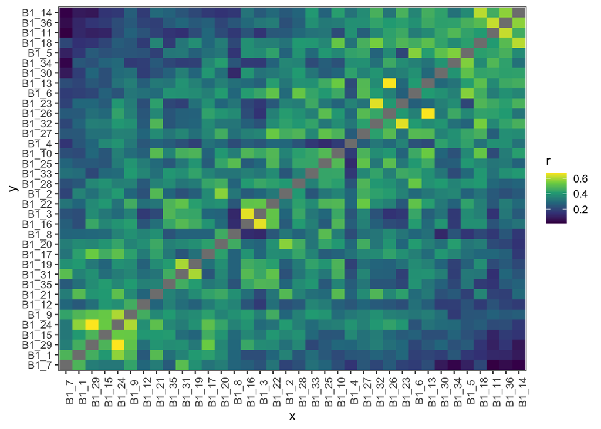

```r
capacidad |>
  select(-id) |>
  corrr::correlate() |>
  corrr::rearrange(method = "PCA") |>
  corrr::stretch() |>
  mutate_at(1:2, fct_inorder) |>
  ggplot(aes(x,y,fill=r)) +
  geom_tile()+
  theme(axis.text.x= element_text(angle = 90))+
  scale_fill_viridis_c()
```

### Análisis Paralelo

El análisis paralelo nos puede ayudar a determinar el numero optimo de factores. Vamos a hacerlo tanto en base a correlaciones policóricas (más adecuado), como en base a correlaciones pearson (más comun)

```r
set.seed(124)
parallel <- capacidad |>
  select(-id) |>
  psych::fa.parallel(plot = F)
```

```
## Parallel analysis suggests that the number of factors =  5  and the number of components =  4
```

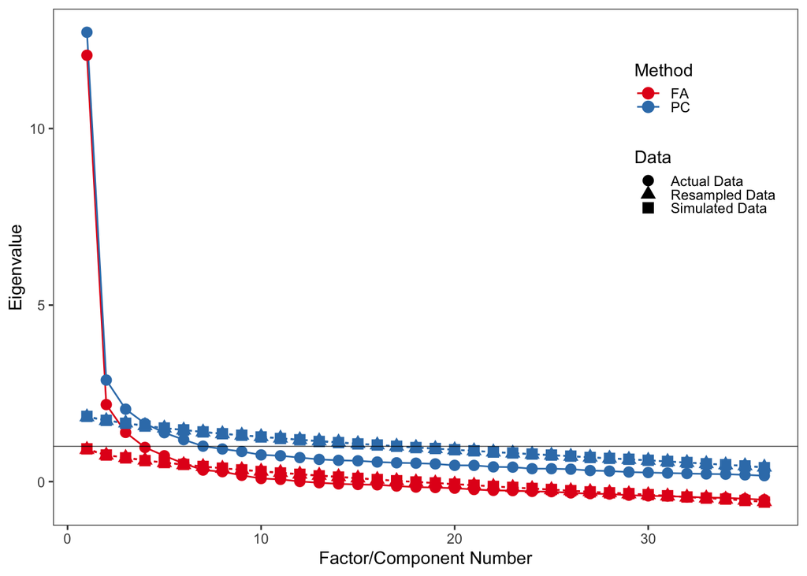

```r
parallel |>
  Ben::plot_parallel()
```

El análisis paralelo sugiere 5 factores, o 4 componentes.

Veamos si lo replicamos usando correlaciones policóricas.

```r
set.seed(1252)
parallel_poly <-
  capacidad |>
  select(-id) |>
  psych::fa.parallel(cor = 'poly',plot = F)
```

```
## Parallel analysis suggests that the number of factors =  6  and the number of components =  4
```

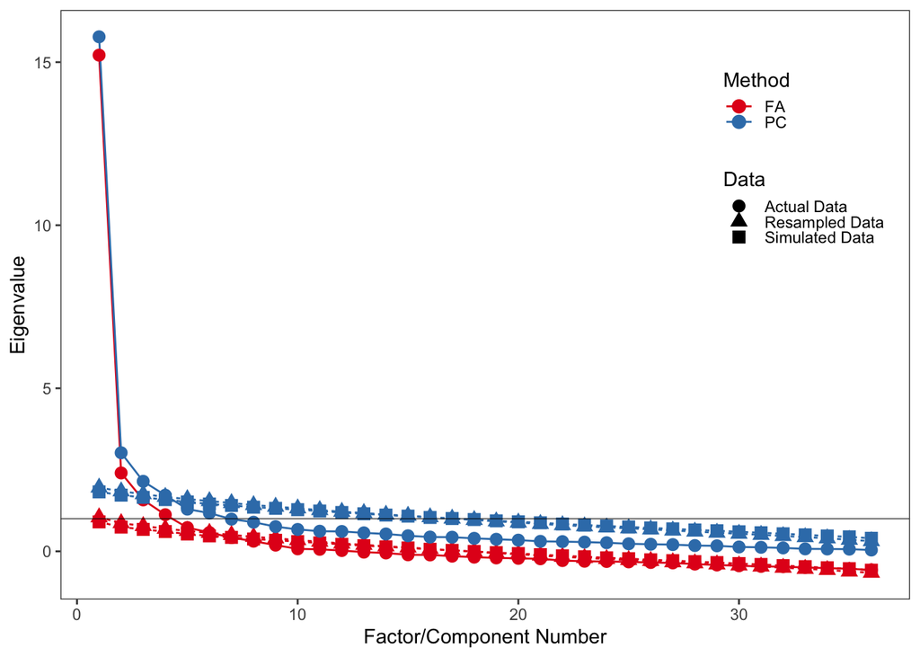

```r
parallel_poly |>
  Ben::plot_parallel()
```

El análisis paralelo, con correlaciones policóricas sugiere 6 factores, o 4 componentes.

### Extracción

Un modelo de 5 factores parece acomodarse adecuadamente a los datos. Haga click en los tabs correspondientes.

```r
# Settings

# Usar rotación promax
rotate = 'promax'
# Usar unweighted least squares
fm = 'uls'
# Usar correlaciones policóricas
cor = "poly"
```

#### 5 factores

| item | ULS4 | ULS3 | ULS1 | ULS2 | ULS5 |
| --- | --- | --- | --- | --- | --- |
| Me siento capaz de manejar el estrés en mis actividades académicas y/o laborales. | 0.78 | 0.03 | −0.02 | −0.03 | −0.01 |
| Me siento capaz de manejar las responsabilidades relacionadas con mis actividades académicas y/o laborales. | 0.77 | −0.01 | 0.00 | 0.10 | 0.10 |
| Me siento capaz de organizar mis actividades académicas y/o laborales para terminarlo a tiempo. | 0.72 | 0.29 | −0.17 | −0.10 | 0.09 |
| Me siento capaz de ser autónomo en mis actividades académicas y/o laborales. | 0.71 | 0.14 | 0.01 | −0.13 | 0.15 |
| Me siento capaz de asumir distintas tareas en mis actividades académicas y/o laborales. | 0.62 | 0.22 | 0.02 | 0.09 | −0.03 |
| Me siento capaz de mantener la objetividad en mis actividades académicas y/o laborales. | 0.58 | 0.06 | −0.02 | 0.09 | 0.20 |
| Me siento capaz de sentir confianza en mí mismo y demostrarlo. | 0.53 | −0.10 | 0.24 | 0.22 | −0.08 |
| Me siento capaz de trabajar bajo presión. | 0.51 | 0.17 | 0.19 | −0.07 | −0.28 |
| Me siento capaz de tener la curiosidad necesaria para buscar y encontrar información adicional. | 0.35 | 0.07 | 0.24 | 0.02 | 0.02 |
| Los otros piensan que soy capaz de manejar mis responsabilidades académicas y/o laborales. | 0.06 | 0.93 | −0.16 | −0.12 | 0.12 |
| Los otros piensan que soy capaz de manejar mi tiempo para realizar mis actividades académicas y/o laborales dentro de los plazos establecidos. | 0.13 | 0.84 | −0.24 | 0.08 | 0.07 |
| Los otros piensan que resisto bien la presión. | 0.18 | 0.65 | 0.13 | 0.00 | −0.14 |
| Los otros piensan que soy capaz de realizar tareas diversas de manera muy satisfactoria. | 0.12 | 0.62 | 0.23 | −0.13 | 0.07 |
| Los otros piensan que soy muy autónomo. | 0.29 | 0.53 | 0.02 | −0.08 | 0.08 |
| Los otros piensan que soy capaz de manejar el estrés. | 0.23 | 0.52 | 0.05 | 0.17 | −0.17 |
| Los otros piensan que soy una persona segura de sí misma. | −0.09 | 0.51 | 0.37 | 0.23 | −0.17 |
| Los otros piensan que tengo una argumentación analítica y práctica. | −0.16 | 0.46 | 0.39 | 0.05 | 0.17 |
| Los otros piensan que soy capaz de proponer nuevas ideas cuando la situación lo demanda. | −0.01 | 0.07 | 0.76 | 0.05 | −0.10 |
| Los otros piensan que tengo la capacidad de defender mis ideas si hace falta. | −0.03 | 0.18 | 0.64 | −0.01 | 0.14 |
| Me siento capaz de sustentar mi discurso a partir de hechos concretos. | 0.33 | −0.05 | 0.64 | −0.20 | 0.17 |
| Me siento capaz de encontrar ideas innovadoras. | 0.36 | −0.23 | 0.57 | 0.02 | −0.07 |
| Me siento capaz de dirigir a otras personas. | 0.12 | −0.16 | 0.56 | 0.22 | 0.16 |
| Los otros piensan que tengo capacidades de líder. | −0.14 | 0.17 | 0.53 | 0.28 | 0.02 |
| Me siento capaz de defender mis ideas cuando la situación lo demanda. | 0.30 | −0.09 | 0.41 | −0.07 | 0.27 |
| Los otros piensan que soy capaz de ser objetivo en mis actividades académicas y/o laborales. | 0.11 | 0.27 | 0.33 | 0.06 | 0.15 |
| Me siento capaz de tener buenas relaciones con las personas. | 0.31 | −0.27 | −0.02 | 0.79 | 0.07 |
| Los otros piensan que tengo facilidad para establecer buenas relaciones con los demás. | −0.23 | 0.12 | −0.06 | 0.77 | 0.20 |
| Me siento capaz de comunicarme sin problemas con mis compañeros. | 0.28 | −0.12 | 0.05 | 0.65 | 0.03 |
| Los otros piensan que soy capaz de comunicarme bien con los demás. | −0.15 | 0.19 | 0.17 | 0.62 | 0.07 |
| Los otros piensan que tengo la capacidad de alentar a los demás. | −0.15 | 0.14 | 0.00 | 0.51 | 0.39 |
| Los otros piensan que soy una persona curiosa y abierta a nuevos conocimientos. | 0.09 | 0.29 | 0.15 | 0.46 | −0.15 |
| Me siento capaz de dar buenos consejos. | 0.03 | −0.16 | 0.29 | 0.01 | 0.70 |
| Me siento capaz de escuchar a los otros. | 0.34 | 0.00 | −0.24 | 0.13 | 0.65 |
| Los otros piensan que soy capaz de dar buenos consejos. | −0.22 | 0.37 | 0.29 | −0.14 | 0.61 |
| Me siento capaz de alentar a las personas para que den lo mejor de sí mismas. | −0.09 | −0.13 | 0.10 | 0.45 | 0.55 |
| Los otros piensan que tengo la capacidad de escucha desarrollada. | 0.08 | 0.24 | −0.19 | 0.27 | 0.52 |

#### 1 factor

| item | ULS1 |
| --- | --- |
| Los otros piensan que tengo la capacidad de defender mis ideas si hace falta. | 0.74 |
| Los otros piensan que soy capaz de realizar tareas diversas de manera muy satisfactoria. | 0.73 |
| Los otros piensan que soy capaz de ser objetivo en mis actividades académicas y/o laborales. | 0.73 |
| Los otros piensan que soy una persona segura de sí misma. | 0.72 |
| Los otros piensan que tengo una argumentación analítica y práctica. | 0.72 |
| Me siento capaz de manejar las responsabilidades relacionadas con mis actividades académicas y/o laborales. | 0.71 |
| Me siento capaz de sustentar mi discurso a partir de hechos concretos. | 0.70 |
| Me siento capaz de asumir distintas tareas en mis actividades académicas y/o laborales. | 0.70 |
| Me siento capaz de dirigir a otras personas. | 0.70 |
| Los otros piensan que tengo capacidades de líder. | 0.70 |
| Los otros piensan que soy capaz de comunicarme bien con los demás. | 0.69 |
| Los otros piensan que soy una persona curiosa y abierta a nuevos conocimientos. | 0.68 |
| Me siento capaz de comunicarme sin problemas con mis compañeros. | 0.68 |
| Los otros piensan que resisto bien la presión. | 0.67 |
| Me siento capaz de mantener la objetividad en mis actividades académicas y/o laborales. | 0.67 |
| Los otros piensan que soy capaz de proponer nuevas ideas cuando la situación lo demanda. | 0.66 |
| Los otros piensan que soy capaz de manejar mi tiempo para realizar mis actividades académicas y/o laborales dentro de los plazos establecidos. | 0.66 |
| Los otros piensan que soy capaz de manejar el estrés. | 0.66 |
| Los otros piensan que soy muy autónomo. | 0.66 |
| Me siento capaz de ser autónomo en mis actividades académicas y/o laborales. | 0.66 |
| Me siento capaz de sentir confianza en mí mismo y demostrarlo. | 0.65 |
| Los otros piensan que soy capaz de dar buenos consejos. | 0.64 |
| Me siento capaz de tener buenas relaciones con las personas. | 0.64 |
| Los otros piensan que soy capaz de manejar mis responsabilidades académicas y/o laborales. | 0.63 |
| Los otros piensan que tengo la capacidad de alentar a los demás. | 0.62 |
| Me siento capaz de defender mis ideas cuando la situación lo demanda. | 0.62 |
| Me siento capaz de organizar mis actividades académicas y/o laborales para terminarlo a tiempo. | 0.62 |
| Los otros piensan que tengo la capacidad de escucha desarrollada. | 0.62 |
| Me siento capaz de alentar a las personas para que den lo mejor de sí mismas. | 0.59 |
| Me siento capaz de dar buenos consejos. | 0.58 |
| Los otros piensan que tengo facilidad para establecer buenas relaciones con los demás. | 0.58 |
| Me siento capaz de manejar el estrés en mis actividades académicas y/o laborales. | 0.56 |
| Me siento capaz de tener la curiosidad necesaria para buscar y encontrar información adicional. | 0.55 |
| Me siento capaz de escuchar a los otros. | 0.55 |
| Me siento capaz de encontrar ideas innovadoras. | 0.53 |
| Me siento capaz de trabajar bajo presión. | 0.46 |

#### 2 factores

| item | ULS1 | ULS2 |
| --- | --- | --- |
| Me siento capaz de manejar el estrés en mis actividades académicas y/o laborales. | 0.88 | −0.27 |
| Me siento capaz de organizar mis actividades académicas y/o laborales para terminarlo a tiempo. | 0.87 | −0.20 |
| Me siento capaz de ser autónomo en mis actividades académicas y/o laborales. | 0.85 | −0.14 |
| Me siento capaz de trabajar bajo presión. | 0.82 | −0.32 |
| Me siento capaz de asumir distintas tareas en mis actividades académicas y/o laborales. | 0.82 | −0.05 |
| Me siento capaz de manejar las responsabilidades relacionadas con mis actividades académicas y/o laborales. | 0.81 | −0.04 |
| Me siento capaz de sentir confianza en mí mismo y demostrarlo. | 0.64 | 0.06 |
| Los otros piensan que resisto bien la presión. | 0.61 | 0.12 |
| Me siento capaz de mantener la objetividad en mis actividades académicas y/o laborales. | 0.61 | 0.12 |
| Me siento capaz de sustentar mi discurso a partir de hechos concretos. | 0.59 | 0.17 |
| Los otros piensan que soy muy autónomo. | 0.59 | 0.12 |
| Los otros piensan que soy capaz de manejar el estrés. | 0.57 | 0.15 |
| Los otros piensan que soy capaz de realizar tareas diversas de manera muy satisfactoria. | 0.54 | 0.26 |
| Me siento capaz de encontrar ideas innovadoras. | 0.53 | 0.04 |
| Me siento capaz de tener la curiosidad necesaria para buscar y encontrar información adicional. | 0.53 | 0.07 |
| Los otros piensan que soy capaz de manejar mi tiempo para realizar mis actividades académicas y/o laborales dentro de los plazos establecidos. | 0.44 | 0.28 |
| Los otros piensan que soy capaz de manejar mis responsabilidades académicas y/o laborales. | 0.44 | 0.25 |
| Me siento capaz de defender mis ideas cuando la situación lo demanda. | 0.41 | 0.26 |
| Los otros piensan que soy capaz de proponer nuevas ideas cuando la situación lo demanda. | 0.36 | 0.36 |
| Los otros piensan que tengo facilidad para establecer buenas relaciones con los demás. | −0.33 | 0.98 |
| Me siento capaz de alentar a las personas para que den lo mejor de sí mismas. | −0.29 | 0.94 |
| Los otros piensan que tengo la capacidad de alentar a los demás. | −0.24 | 0.94 |
| Los otros piensan que soy capaz de comunicarme bien con los demás. | −0.07 | 0.83 |
| Los otros piensan que soy capaz de dar buenos consejos. | −0.04 | 0.74 |
| Me siento capaz de dar buenos consejos. | −0.07 | 0.71 |
| Los otros piensan que tengo la capacidad de escucha desarrollada. | −0.01 | 0.69 |
| Los otros piensan que tengo capacidades de líder. | 0.13 | 0.64 |
| Los otros piensan que tengo una argumentación analítica y práctica. | 0.18 | 0.61 |
| Me siento capaz de tener buenas relaciones con las personas. | 0.13 | 0.57 |
| Me siento capaz de dirigir a otras personas. | 0.23 | 0.53 |
| Me siento capaz de comunicarme sin problemas con mis compañeros. | 0.21 | 0.53 |
| Los otros piensan que tengo la capacidad de defender mis ideas si hace falta. | 0.31 | 0.50 |
| Me siento capaz de escuchar a los otros. | 0.13 | 0.47 |
| Los otros piensan que soy una persona segura de sí misma. | 0.33 | 0.45 |
| Los otros piensan que soy una persona curiosa y abierta a nuevos conocimientos. | 0.31 | 0.43 |
| Los otros piensan que soy capaz de ser objetivo en mis actividades académicas y/o laborales. | 0.36 | 0.43 |

#### 3 factores

| item | ULS2 | ULS1 | ULS3 |
| --- | --- | --- | --- |
| Me siento capaz de alentar a las personas para que den lo mejor de sí mismas. | 0.95 | −0.11 | −0.16 |
| Los otros piensan que tengo facilidad para establecer buenas relaciones con los demás. | 0.86 | −0.28 | 0.10 |
| Los otros piensan que tengo la capacidad de alentar a los demás. | 0.82 | −0.22 | 0.13 |
| Me siento capaz de dar buenos consejos. | 0.72 | 0.06 | −0.11 |
| Los otros piensan que soy capaz de comunicarme bien con los demás. | 0.70 | −0.12 | 0.24 |
| Me siento capaz de tener buenas relaciones con las personas. | 0.70 | 0.35 | −0.30 |
| Me siento capaz de comunicarme sin problemas con mis compañeros. | 0.58 | 0.34 | −0.13 |
| Los otros piensan que tengo la capacidad de escucha desarrollada. | 0.58 | −0.04 | 0.17 |
| Me siento capaz de dirigir a otras personas. | 0.56 | 0.31 | −0.05 |
| Los otros piensan que soy capaz de dar buenos consejos. | 0.54 | −0.22 | 0.43 |
| Me siento capaz de escuchar a los otros. | 0.50 | 0.22 | −0.09 |
| Los otros piensan que tengo capacidades de líder. | 0.50 | 0.01 | 0.31 |
| Los otros piensan que tengo la capacidad de defender mis ideas si hace falta. | 0.37 | 0.15 | 0.34 |
| Los otros piensan que soy capaz de proponer nuevas ideas cuando la situación lo demanda. | 0.27 | 0.24 | 0.26 |
| Me siento capaz de manejar el estrés en mis actividades académicas y/o laborales. | −0.18 | 0.86 | −0.03 |
| Me siento capaz de manejar las responsabilidades relacionadas con mis actividades académicas y/o laborales. | 0.05 | 0.85 | −0.07 |
| Me siento capaz de ser autónomo en mis actividades académicas y/o laborales. | −0.10 | 0.76 | 0.11 |
| Me siento capaz de organizar mis actividades académicas y/o laborales para terminarlo a tiempo. | −0.20 | 0.70 | 0.22 |
| Me siento capaz de sentir confianza en mí mismo y demostrarlo. | 0.15 | 0.69 | −0.09 |
| Me siento capaz de asumir distintas tareas en mis actividades académicas y/o laborales. | −0.05 | 0.68 | 0.20 |
| Me siento capaz de trabajar bajo presión. | −0.32 | 0.64 | 0.22 |
| Me siento capaz de mantener la objetividad en mis actividades académicas y/o laborales. | 0.16 | 0.61 | 0.00 |
| Me siento capaz de encontrar ideas innovadoras. | 0.13 | 0.59 | −0.11 |
| Me siento capaz de sustentar mi discurso a partir de hechos concretos. | 0.18 | 0.54 | 0.09 |
| Me siento capaz de tener la curiosidad necesaria para buscar y encontrar información adicional. | 0.08 | 0.46 | 0.11 |
| Me siento capaz de defender mis ideas cuando la situación lo demanda. | 0.30 | 0.44 | −0.02 |
| Los otros piensan que soy capaz de manejar mis responsabilidades académicas y/o laborales. | −0.10 | −0.07 | 0.92 |
| Los otros piensan que soy capaz de manejar mi tiempo para realizar mis actividades académicas y/o laborales dentro de los plazos establecidos. | −0.01 | 0.00 | 0.80 |
| Los otros piensan que resisto bien la presión. | −0.13 | 0.19 | 0.73 |
| Los otros piensan que soy capaz de realizar tareas diversas de manera muy satisfactoria. | 0.00 | 0.14 | 0.72 |
| Los otros piensan que soy una persona segura de sí misma. | 0.21 | 0.00 | 0.63 |
| Los otros piensan que tengo una argumentación analítica y práctica. | 0.37 | −0.11 | 0.58 |
| Los otros piensan que soy capaz de manejar el estrés. | −0.04 | 0.24 | 0.56 |
| Los otros piensan que soy muy autónomo. | −0.06 | 0.27 | 0.55 |
| Los otros piensan que soy capaz de ser objetivo en mis actividades académicas y/o laborales. | 0.30 | 0.19 | 0.36 |
| Los otros piensan que soy una persona curiosa y abierta a nuevos conocimientos. | 0.31 | 0.15 | 0.34 |

#### 4 factores

| item | ULS4 | ULS1 | ULS2 | ULS3 |
| --- | --- | --- | --- | --- |
| Me siento capaz de manejar el estrés en mis actividades académicas y/o laborales. | 0.81 | −0.05 | −0.06 | 0.01 |
| Me siento capaz de manejar las responsabilidades relacionadas con mis actividades académicas y/o laborales. | 0.80 | 0.00 | 0.12 | −0.02 |
| Me siento capaz de ser autónomo en mis actividades académicas y/o laborales. | 0.76 | −0.13 | 0.06 | 0.16 |
| Me siento capaz de organizar mis actividades académicas y/o laborales para terminarlo a tiempo. | 0.74 | −0.22 | 0.01 | 0.27 |
| Me siento capaz de asumir distintas tareas en mis actividades académicas y/o laborales. | 0.63 | 0.09 | −0.02 | 0.18 |
| Me siento capaz de mantener la objetividad en mis actividades académicas y/o laborales. | 0.61 | −0.04 | 0.23 | 0.05 |
| Me siento capaz de sentir confianza en mí mismo y demostrarlo. | 0.56 | 0.34 | 0.00 | −0.13 |
| Me siento capaz de trabajar bajo presión. | 0.53 | 0.23 | −0.36 | 0.14 |
| Me siento capaz de sustentar mi discurso a partir de hechos concretos. | 0.44 | 0.35 | 0.04 | 0.03 |
| Me siento capaz de tener la curiosidad necesaria para buscar y encontrar información adicional. | 0.39 | 0.21 | 0.01 | 0.07 |
| Me siento capaz de defender mis ideas cuando la situación lo demanda. | 0.38 | 0.20 | 0.21 | −0.03 |
| Los otros piensan que soy capaz de proponer nuevas ideas cuando la situación lo demanda. | 0.06 | 0.74 | −0.09 | 0.07 |
| Los otros piensan que tengo capacidades de líder. | −0.11 | 0.67 | 0.15 | 0.14 |
| Los otros piensan que soy una persona segura de sí misma. | −0.11 | 0.62 | −0.07 | 0.44 |
| Los otros piensan que soy capaz de comunicarme bien con los demás. | −0.19 | 0.55 | 0.38 | 0.12 |
| Me siento capaz de dirigir a otras personas. | 0.19 | 0.55 | 0.26 | −0.14 |
| Los otros piensan que tengo la capacidad de defender mis ideas si hace falta. | 0.06 | 0.53 | 0.12 | 0.20 |
| Los otros piensan que soy una persona curiosa y abierta a nuevos conocimientos. | 0.06 | 0.50 | 0.07 | 0.21 |
| Me siento capaz de encontrar ideas innovadoras. | 0.44 | 0.49 | −0.10 | −0.20 |
| Me siento capaz de comunicarme sin problemas con mis compañeros. | 0.25 | 0.41 | 0.35 | −0.17 |
| Los otros piensan que soy capaz de ser objetivo en mis actividades académicas y/o laborales. | 0.15 | 0.31 | 0.17 | 0.28 |
| Me siento capaz de alentar a las personas para que den lo mejor de sí mismas. | −0.07 | 0.17 | 0.80 | −0.12 |
| Me siento capaz de escuchar a los otros. | 0.37 | −0.37 | 0.73 | 0.04 |
| Me siento capaz de dar buenos consejos. | 0.11 | 0.03 | 0.69 | −0.05 |
| Los otros piensan que tengo la capacidad de escucha desarrollada. | 0.07 | −0.14 | 0.68 | 0.24 |
| Los otros piensan que tengo la capacidad de alentar a los demás. | −0.18 | 0.22 | 0.67 | 0.11 |
| Los otros piensan que tengo facilidad para establecer buenas relaciones con los demás. | −0.29 | 0.39 | 0.60 | 0.04 |
| Los otros piensan que soy capaz de dar buenos consejos. | −0.13 | 0.05 | 0.53 | 0.41 |
| Me siento capaz de tener buenas relaciones con las personas. | 0.26 | 0.39 | 0.45 | −0.31 |
| Los otros piensan que soy capaz de manejar mis responsabilidades académicas y/o laborales. | 0.03 | −0.12 | 0.06 | 0.89 |
| Los otros piensan que soy capaz de manejar mi tiempo para realizar mis actividades académicas y/o laborales dentro de los plazos establecidos. | 0.08 | −0.06 | 0.11 | 0.76 |
| Los otros piensan que soy capaz de realizar tareas diversas de manera muy satisfactoria. | 0.15 | 0.19 | −0.01 | 0.61 |
| Los otros piensan que resisto bien la presión. | 0.16 | 0.26 | −0.16 | 0.59 |
| Los otros piensan que soy muy autónomo. | 0.30 | 0.02 | 0.03 | 0.51 |
| Los otros piensan que tengo una argumentación analítica y práctica. | −0.12 | 0.39 | 0.20 | 0.45 |
| Los otros piensan que soy capaz de manejar el estrés. | 0.20 | 0.28 | −0.10 | 0.44 |

#### 6 factores

| item | ULS3 | ULS4 | ULS5 | ULS2 | ULS6 | ULS1 |
| --- | --- | --- | --- | --- | --- | --- |
| Los otros piensan que soy capaz de manejar mis responsabilidades académicas y/o laborales. | 0.99 | 0.08 | −0.12 | 0.07 | −0.25 | 0.00 |
| Los otros piensan que soy capaz de manejar mi tiempo para realizar mis actividades académicas y/o laborales dentro de los plazos establecidos. | 0.90 | 0.14 | 0.08 | 0.03 | −0.30 | −0.04 |
| Los otros piensan que resisto bien la presión. | 0.65 | 0.20 | −0.01 | −0.12 | 0.18 | −0.09 |
| Los otros piensan que soy una persona segura de sí misma. | 0.62 | −0.15 | 0.28 | −0.24 | 0.19 | 0.19 |
| Los otros piensan que soy capaz de realizar tareas diversas de manera muy satisfactoria. | 0.62 | 0.15 | −0.16 | 0.09 | 0.22 | 0.00 |
| Los otros piensan que soy capaz de manejar el estrés. | 0.56 | 0.21 | 0.19 | −0.18 | 0.04 | −0.01 |
| Los otros piensan que soy muy autónomo. | 0.52 | 0.30 | −0.09 | 0.09 | 0.05 | −0.02 |
| Los otros piensan que tengo una argumentación analítica y práctica. | 0.48 | −0.14 | 0.02 | 0.19 | 0.28 | 0.09 |
| Los otros piensan que soy capaz de ser objetivo en mis actividades académicas y/o laborales. | 0.34 | 0.06 | 0.08 | 0.10 | 0.16 | 0.25 |
| Me siento capaz de manejar el estrés en mis actividades académicas y/o laborales. | 0.03 | 0.69 | 0.02 | −0.06 | −0.02 | 0.16 |
| Me siento capaz de asumir distintas tareas en mis actividades académicas y/o laborales. | 0.10 | 0.68 | 0.03 | 0.09 | 0.29 | −0.26 |
| Me siento capaz de manejar las responsabilidades relacionadas con mis actividades académicas y/o laborales. | −0.01 | 0.68 | 0.14 | 0.07 | −0.01 | 0.17 |
| Me siento capaz de organizar mis actividades académicas y/o laborales para terminarlo a tiempo. | 0.29 | 0.67 | −0.06 | 0.05 | −0.15 | 0.08 |
| Me siento capaz de ser autónomo en mis actividades académicas y/o laborales. | 0.12 | 0.66 | −0.12 | 0.13 | 0.04 | 0.11 |
| Me siento capaz de mantener la objetividad en mis actividades académicas y/o laborales. | 0.07 | 0.51 | 0.11 | 0.18 | −0.06 | 0.15 |
| Me siento capaz de trabajar bajo presión. | 0.12 | 0.50 | −0.05 | −0.25 | 0.33 | −0.07 |
| Me siento capaz de tener buenas relaciones con las personas. | −0.26 | 0.23 | 0.78 | 0.12 | 0.00 | 0.06 |
| Los otros piensan que tengo facilidad para establecer buenas relaciones con los demás. | 0.12 | −0.21 | 0.69 | 0.31 | −0.03 | −0.13 |
| Me siento capaz de comunicarme sin problemas con mis compañeros. | −0.08 | 0.20 | 0.66 | 0.05 | 0.01 | 0.11 |
| Los otros piensan que soy capaz de comunicarme bien con los demás. | 0.27 | −0.20 | 0.62 | 0.07 | 0.04 | 0.11 |
| Los otros piensan que soy una persona curiosa y abierta a nuevos conocimientos. | 0.25 | 0.12 | 0.40 | −0.03 | 0.31 | −0.21 |
| Me siento capaz de alentar a las personas para que den lo mejor de sí mismas. | −0.21 | −0.04 | 0.32 | 0.72 | 0.19 | −0.11 |
| Me siento capaz de escuchar a los otros. | −0.03 | 0.35 | 0.06 | 0.68 | −0.22 | 0.02 |
| Me siento capaz de dar buenos consejos. | −0.14 | 0.00 | −0.03 | 0.68 | 0.11 | 0.28 |
| Los otros piensan que soy capaz de dar buenos consejos. | 0.37 | −0.16 | −0.23 | 0.63 | 0.18 | 0.09 |
| Los otros piensan que tengo la capacidad de alentar a los demás. | 0.08 | −0.08 | 0.38 | 0.55 | 0.12 | −0.22 |
| Los otros piensan que tengo la capacidad de escucha desarrollada. | 0.27 | 0.08 | 0.22 | 0.53 | −0.26 | 0.05 |
| Los otros piensan que soy capaz de proponer nuevas ideas cuando la situación lo demanda. | 0.03 | −0.02 | 0.01 | −0.03 | 0.79 | 0.07 |
| Me siento capaz de encontrar ideas innovadoras. | −0.29 | 0.32 | 0.01 | −0.03 | 0.63 | 0.12 |
| Los otros piensan que tengo capacidades de líder. | 0.19 | −0.15 | 0.25 | 0.06 | 0.45 | 0.10 |
| Me siento capaz de dirigir a otras personas. | −0.15 | 0.07 | 0.22 | 0.18 | 0.44 | 0.24 |
| Los otros piensan que tengo la capacidad de defender mis ideas si hace falta. | 0.23 | −0.07 | 0.01 | 0.09 | 0.44 | 0.31 |
| Me siento capaz de tener la curiosidad necesaria para buscar y encontrar información adicional. | −0.02 | 0.37 | −0.04 | 0.12 | 0.41 | −0.10 |
| Me siento capaz de defender mis ideas cuando la situación lo demanda. | 0.01 | 0.16 | 0.00 | 0.12 | 0.08 | 0.60 |
| Me siento capaz de sustentar mi discurso a partir de hechos concretos. | 0.01 | 0.22 | −0.14 | 0.06 | 0.40 | 0.49 |
| Me siento capaz de sentir confianza en mí mismo y demostrarlo. | −0.01 | 0.38 | 0.37 | −0.23 | 0.00 | 0.46 |

## Analisis Factorial Confirmatorio

### Modelo original de 5 factores - Todos los ítems

De acuerdo a los análisis preliminares, podemos realizar un análisis factorial confirmatorio.

```r
library(lavaan)
model <- c(paste("f1 =~ ",paste0("B1_",1:9, collapse = '+')),
paste("f2 =~ ",paste0("B1_",10:17, collapse = '+')),
paste("f3 =~ ",paste0("B1_",18:25, collapse = '+')),
paste("f4 =~ ",paste0("B1_",26:31, collapse = '+')),
paste("f5 =~ ",paste0("B1_",32:36, collapse = '+')))
```

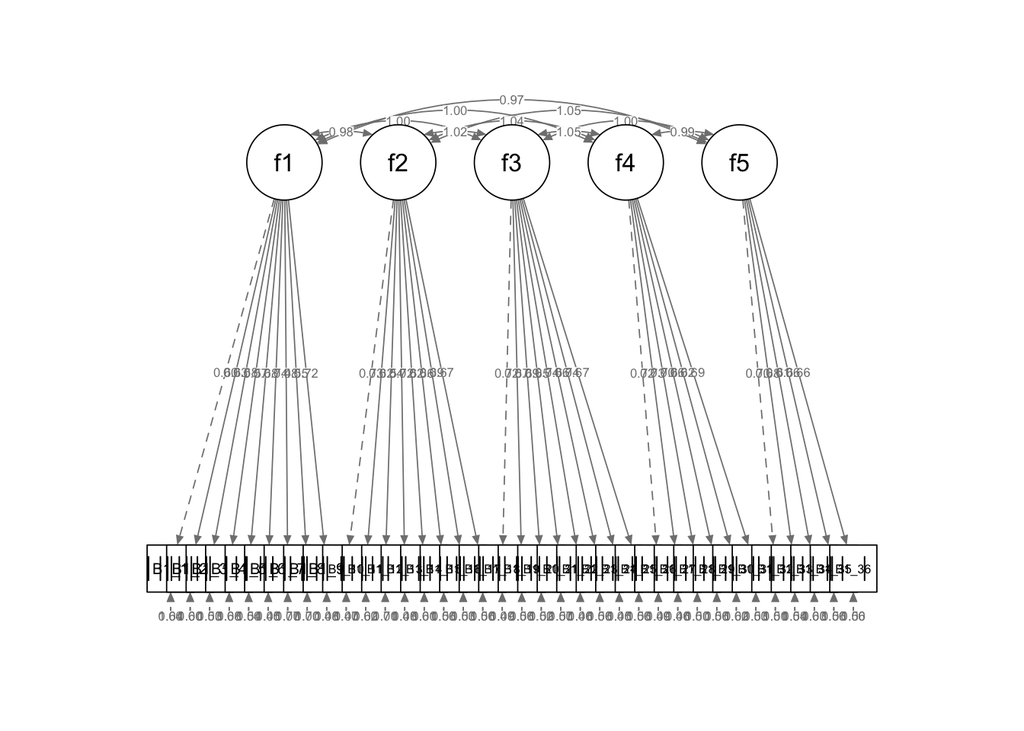

```r
fit <- cfa(model,data = capacidad, ordered = T)
#summary(fit, rsquare = T, fit.measures = T, standardized = T)
semPlot::semPaths(fit,whatLabels = 'std', style = 'lisrel', intercepts= F)
```

El modelo tiene un fit bastante adecuado. $\chi^2$ = 2092.88 [df = 584,N = 234], p <.001***, CFI = .95, TLI = .95, RMSEA = .13 [95% CI = .13 - .14], SRMR = .10

```r
min = fit |> broom::tidy() |> filter(op == "=~") |> pull(std.all) |> min() |> numformat()
max = fit |> broom::tidy() |> filter(op == "=~") |> pull(std.all) |> max() |> numformat()
```

Aquí podemos ver las cargas factoriales. Todas son significativas (p < .001), y de tamaños relativamente considerables (rango = .48 - .74.

```r
fit |>
  broom::tidy() |>
  filter(op == "=~") |>
  select(term, std.all, p.value) |>
  separate(term, c("Factor", "Item"), "=~") |>
  group_by(Factor) |>
  gt::gt() |>
  fmt_number(3)
```

| Item | std.all | p.value |
| --- | --- | --- |
| f1 |  |  |
| B1_1 | 0.60 | NA |
| B1_2 | 0.63 | 0 |
| B1_3 | 0.68 | 0 |
| B1_4 | 0.57 | 0 |
| B1_5 | 0.68 | 0 |
| B1_6 | 0.74 | 0 |
| B1_7 | 0.48 | 0 |
| B1_8 | 0.55 | 0 |
| B1_9 | 0.72 | 0 |
| f2 |  |  |
| B1_10 | 0.73 | NA |
| B1_11 | 0.62 | 0 |
| B1_12 | 0.54 | 0 |
| B1_13 | 0.72 | 0 |
| B1_14 | 0.62 | 0 |
| B1_15 | 0.66 | 0 |
| B1_16 | 0.69 | 0 |
| B1_17 | 0.67 | 0 |
| f3 |  |  |
| B1_18 | 0.72 | NA |
| B1_19 | 0.67 | 0 |
| B1_20 | 0.69 | 0 |
| B1_21 | 0.65 | 0 |
| B1_22 | 0.74 | 0 |
| B1_23 | 0.66 | 0 |
| B1_24 | 0.74 | 0 |
| B1_25 | 0.67 | 0 |
| f4 |  |  |
| B1_26 | 0.72 | NA |
| B1_27 | 0.73 | 0 |
| B1_28 | 0.70 | 0 |
| B1_29 | 0.66 | 0 |
| B1_30 | 0.62 | 0 |
| B1_31 | 0.69 | 0 |
| f5 |  |  |
| B1_32 | 0.70 | NA |
| B1_33 | 0.68 | 0 |
| B1_34 | 0.61 | 0 |
| B1_35 | 0.66 | 0 |
| B1_36 | 0.66 | 0 |

Las correlaciones entre factores son las siguientes, lo cual representa un problema dado que no deberían haber correlaciones superiores a 1.00 entre factores.

```r
inspect(fit,what = "std.all")$psi |> as.data.frame() |> rownames_to_column() |> gt() |> fmt_number(2:6)
```

|  | f1 | f2 | f3 | f4 | f5 |
| --- | --- | --- | --- | --- | --- |
| f1 | 1.00 | 0.98 | 1.00 | 1.00 | 0.97 |
| f2 | 0.98 | 1.00 | 1.02 | 1.04 | 1.05 |
| f3 | 1.00 | 1.02 | 1.00 | 1.05 | 1.00 |
| f4 | 1.00 | 1.04 | 1.05 | 1.00 | 0.99 |
| f5 | 0.97 | 1.05 | 1.00 | 0.99 | 1.00 |

### Modelo de dos factores - todos los ítems

Aquí presentamos los resultados del análisis factorial confirmatorio de 2 factores (capacidad subjetiva - ítems que empiezan con “Me siento” y capacidad normativa - items que empiezan con “Los otros piensan”).

```r
library(lavaan)
model = items |>
  arrange(me_siento) |>
  mutate(factor = ifelse(me_siento == 1, "subjetiva","normativa")) |>
  transmute(a = glue::glue("{factor} =~ {var}")) |>
  pull(a)
```

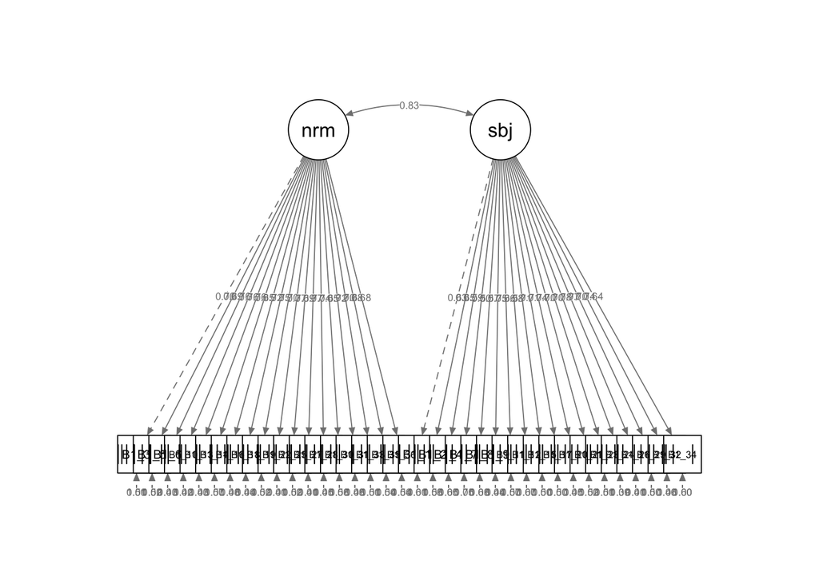

```r
fit <- cfa(model,data = capacidad, ordered = T)
#summary(fit, rsquare = T, fit.measures = T, standardized = T)
semPlot::semPaths(fit,whatLabels = 'std', style = 'lisrel', intercepts= F)
```

El modelo tiene un fit bastante adecuado. $\chi^2$ = 1880.03 [df = 593,N = 234], p <.001***, CFI = .96, TLI = .96, RMSEA = .12 [95% CI = .11 - .12], SRMR = .10

```r
min = fit |> broom::tidy() |> filter(op == "=~") |> pull(std.all) |> min() |> numformat()
max = fit |> broom::tidy() |> filter(op == "=~") |> pull(std.all) |> max() |> numformat()
```

Aquí podemos ver las cargas factoriales. Todas son significativas (p < .001), y de tamaños relativamente considerables (rango = .50 - .78).

```r
fit |>
  broom::tidy() |>
  filter(op == "=~") |>
  select(term, std.all, p.value) |>
  separate(term, c("Factor", "Item"), "=~") |>
  group_by(Factor) |>
  gt::gt() |>
  fmt_number(3)
```

| Item | std.all | p.value |
| --- | --- | --- |
| normativa |  |  |
| B1_3 | 0.70 | NA |
| B1_5 | 0.69 | 0 |
| B1_6 | 0.76 | 0 |
| B1_10 | 0.76 | 0 |
| B1_13 | 0.76 | 0 |
| B1_14 | 0.65 | 0 |
| B1_16 | 0.72 | 0 |
| B1_18 | 0.75 | 0 |
| B1_19 | 0.70 | 0 |
| B1_22 | 0.77 | 0 |
| B1_25 | 0.69 | 0 |
| B1_27 | 0.77 | 0 |
| B1_28 | 0.74 | 0 |
| B1_30 | 0.65 | 0 |
| B1_31 | 0.72 | 0 |
| B1_33 | 0.70 | 0 |
| B1_35 | 0.68 | 0 |
| B1_36 | 0.68 | 0 |
| subjetiva |  |  |
| B1_1 | 0.63 | NA |
| B1_2 | 0.65 | 0 |
| B1_4 | 0.59 | 0 |
| B1_7 | 0.50 | 0 |
| B1_8 | 0.57 | 0 |
| B1_9 | 0.75 | 0 |
| B1_11 | 0.66 | 0 |
| B1_12 | 0.58 | 0 |
| B1_15 | 0.71 | 0 |
| B1_17 | 0.71 | 0 |
| B1_20 | 0.74 | 0 |
| B1_21 | 0.70 | 0 |
| B1_23 | 0.70 | 0 |
| B1_24 | 0.78 | 0 |
| B1_26 | 0.77 | 0 |
| B1_29 | 0.70 | 0 |
| B1_32 | 0.74 | 0 |
| B1_34 | 0.64 | 0 |

Las correlaciones entre factores son las siguientes, si bien son lo suficientemente altas para pensar que los dos factores podrían resumirse en uno solo, no representan un problema en términus estadisticos (no hay problemas de mulitcolinearidad, estadisticos inadmisibles, o casos Heywood, i.e., varianzas negativas).

```r
inspect(fit,what = "std.all")$psi |> as.data.frame() |> rownames_to_column() |> gt() |> fmt_number(2:3)
```

|  | normativa | subjetiva |
| --- | --- | --- |
| normativa | 1.00 | 0.83 |
| subjetiva | 0.83 | 1.00 |

A continuación presentamos la correlación entre ambos facotres.

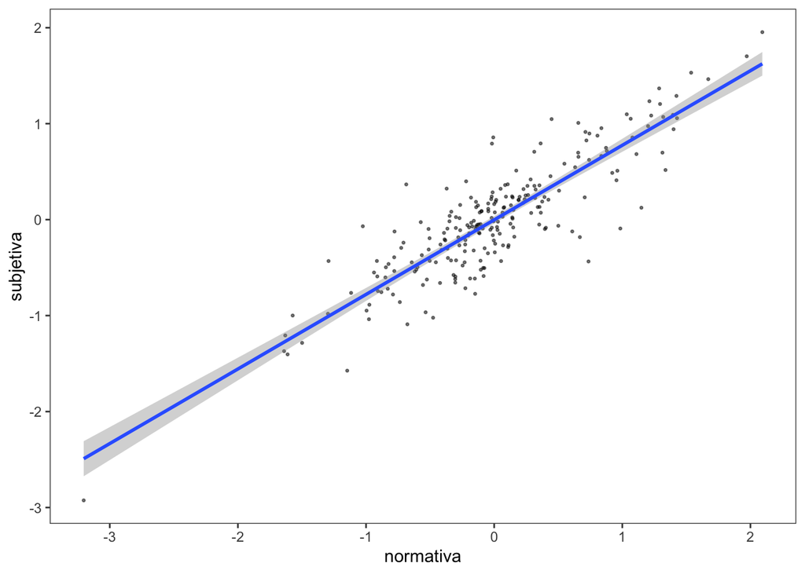

```r
predict(fit) |>
  as_tibble() |>
  ggplot(aes(normativa,subjetiva))+
  geom_point(alpha = .5, size = .5)+
  geom_smooth(method = 'lm')
```

#### Confiabilidad del modelo de dos factores

```r
alfa = capacidad |>
  select(items |> filter(me_siento == 1) |> pull(var)) |>
  psych::alpha()
```

El factor subjetivo tiene un alfa de .905, con correlaciones item total corregidas en el rango de .393 - .720.

```r
alfa = capacidad |>
  select(items |> filter(me_siento == 0) |> pull(var)) |>
  psych::alpha()
```

El factor normativo tiene un alfa de .921, con correlaciones item total corregidas en el rango de .533 - .676.

### Modelo de dos factores - 16 ítems - publicación de los franceses

Aquí presentamos los resultados del análisis factorial confirmatorio de 2 factores (capacidad subjetiva - ítems que empiezan con “Me siento” y capacidad normativa - items que empiezan con “Los otros piensan”). Para este análisis presento el análisis realizado en los 16 items empleados por el equipo de los franceses.

```r
library(lavaan)
model = items |>
  arrange(me_siento) |>
  mutate(factor = ifelse(me_siento == 1, "subjetiva", "normativa")) |>
  filter(
    var %in% c(
      "B1_1",
      "B1_2",
      "B1_3",
      "B1_6",
      "B1_7",
      "B1_9",
      "B1_10",
      "B1_13",
      "B1_19",
      "B1_20",
      "B1_21",
      "B1_22",
      "B1_24",
      "B1_26",
      "B1_27",
      "B1_31"
    )
  ) |>
  transmute(a = glue::glue("{factor} =~ {var}")) |>
  pull(a)
```

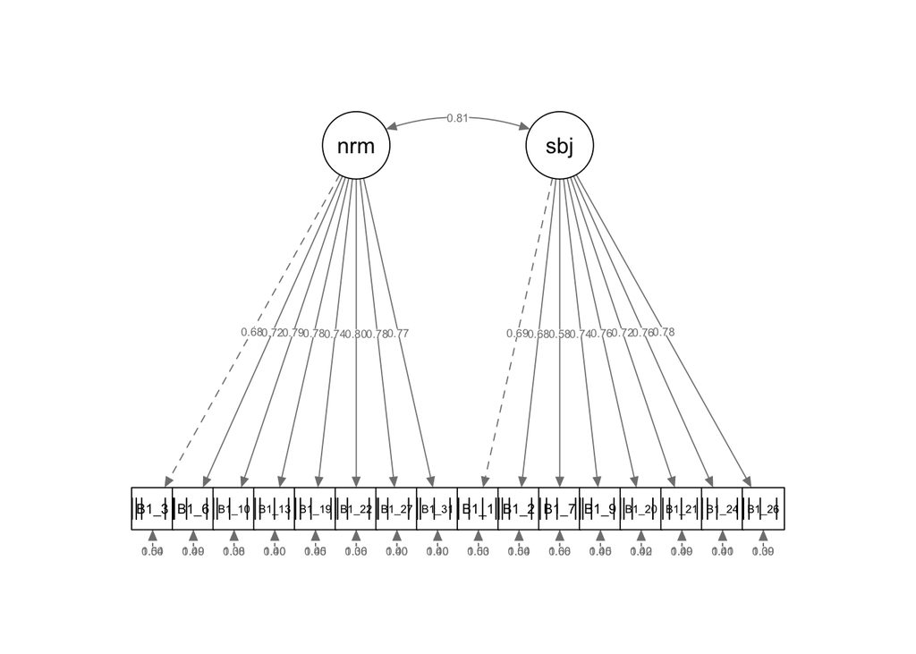

```r
fit <- cfa(model,data = capacidad, ordered = T)
#summary(fit, rsquare = T, fit.measures = T, standardized = T)
semPlot::semPaths(fit,whatLabels = 'std', style = 'lisrel', intercepts= F)
```

El modelo tiene un fit bastante adecuado. $\chi^2$ = 582.33 [df = 103,N = 234], p <.001***, CFI = .97, TLI = .97, RMSEA = .12 [95% CI = .11 - .13], SRMR = .09

```r
min = fit |> broom::tidy() |> filter(op == "=~") |> pull(std.all) |> min() |> numformat()
max = fit |> broom::tidy() |> filter(op == "=~") |> pull(std.all) |> max() |> numformat()
```

Aquí podemos ver las cargas factoriales. Todas son significativas (p < .001), y de tamaños relativamente considerables (rango = .58 - .80).

```r
fit |>
  broom::tidy() |>
  filter(op == "=~") |>
  select(term, std.all, p.value) |>
  separate(term, c("Factor", "Item"), "=~") |>
  group_by(Factor) |>
  gt::gt() |>
  fmt_number(3)
```

| Item | std.all | p.value |
| --- | --- | --- |
| normativa |  |  |
| B1_3 | 0.68 | NA |
| B1_6 | 0.72 | 0 |
| B1_10 | 0.79 | 0 |
| B1_13 | 0.78 | 0 |
| B1_19 | 0.74 | 0 |
| B1_22 | 0.80 | 0 |
| B1_27 | 0.78 | 0 |
| B1_31 | 0.77 | 0 |
| subjetiva |  |  |
| B1_1 | 0.69 | NA |
| B1_2 | 0.68 | 0 |
| B1_7 | 0.58 | 0 |
| B1_9 | 0.74 | 0 |
| B1_20 | 0.76 | 0 |
| B1_21 | 0.72 | 0 |
| B1_24 | 0.76 | 0 |
| B1_26 | 0.78 | 0 |

Las correlaciones entre factores son las siguientes, si bien son lo suficientemente altas para pensar que los dos factores podrían resumirse en uno solo, no representan un problema en términus estadisticos (no hay problemas de mulitcolinearidad, estadisticos inadmisibles, o casos Heywood, i.e., varianzas negativas).

```r
inspect(fit,what = "std.all")$psi |> as.data.frame() |> rownames_to_column() |> gt() |> fmt_number(2:3)
```

|  | normativa | subjetiva |
| --- | --- | --- |
| normativa | 1.00 | 0.81 |
| subjetiva | 0.81 | 1.00 |

A continuación presentamos la correlación entre ambos facotres.

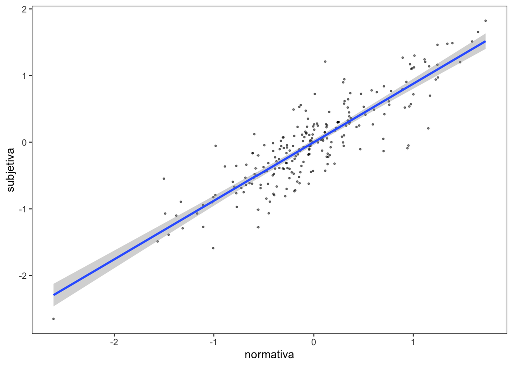

```r
predict(fit) |>
  as_tibble() |>
  ggplot(aes(normativa,subjetiva))+
  geom_point(alpha = .5, size = .5)+
  geom_smooth(method = 'lm')
```

#### Confiabilidad del modelo de dos factores

```r
i = model[str_detect(model,"subjetiva")] |> str_remove_all('subjetiva =~ ')
alfa = capacidad |>
  select(i) |>
  psych::alpha()
```

El factor subjetivo tiene un alfa de .844, con correlaciones item total corregidas en el rango de .473 - .683.

```r
i = model[str_detect(model,"normativa")] |> str_remove_all('normativa =~ ')
alfa = capacidad |>
  select(i) |>
  psych::alpha()
```

El factor normativo tiene un alfa de .863, con correlaciones item total corregidas en el rango de .561 - .680.

## 2 factores - 10 items Oct 31

### Exploratorio

```r
capacidad |>
  select(B1_21,B1_17, B1_20, B1_12, B1_2,
         B1_6, B1_27, B1_10, B1_33, B1_28 )
```

```
## # A tibble: 234 × 10
##    B1_21 B1_17 B1_20 B1_12  B1_2  B1_6 B1_27 B1_10 B1_33 B1_28
##    <dbl> <dbl> <dbl> <dbl> <dbl> <dbl> <dbl> <dbl> <dbl> <dbl>
##  1     3     6     6     6     3     6     6     6     6     5
##  2     6     5     6     1     6     6     6     6     5     6
##  3     5     3     5     5     5     5     3     5     6     5
##  4     5     5     5     5     5     5     5     5     5     5
##  5     3     5     5     6     5     5     5     5     5     5
##  6     1     1     1     1     1     1     1     1     1     1
##  7     3     2     3     5     2     3     5     5     5     5
##  8     5     5     5     3     5     5     6     5     5     6
##  9     3     5     3     3     5     5     5     5     5     5
## 10     5     5     5     5     6     5     5     5     5     5
## # … with 224 more rows
```

```r
capacidad |>
    select(B1_21,B1_17, B1_20, B1_12, B1_2,
         B1_6, B1_27, B1_10, B1_33, B1_28 ) |>
    psych::fa(
      nfactors = 2,
     rotate = "varimax",
      fm = fm,
      cor = cor
    )  |>
       fa_tibble(sort = T) |> left_join(items |> rename(Item = var)) |> select(item, starts_with("ULS")) %>%
  # mutate_at(2:ncol(.), ~Ben::numformat(., n=3)) |>
  gt::gt() |>
  fmt_number(
    columns = paste0("ULS",1:2)
  ) |>
   data_color(
    columns = paste0("ULS",1:2),
    colors = scales::col_numeric(
      palette = c("dark red", "white", "dark green"),
      domain = c(-1, 1)
    )
  )
```

| item | ULS1 | ULS2 |
| --- | --- | --- |
| Los otros piensan que tengo una argumentación analítica y práctica. | 0.77 | 0.26 |
| Los otros piensan que soy una persona curiosa y abierta a nuevos conocimientos. | 0.72 | 0.19 |
| Los otros piensan que tengo la capacidad de defender mis ideas si hace falta. | 0.63 | 0.46 |
| Los otros piensan que soy capaz de ser objetivo en mis actividades académicas y/o laborales. | 0.62 | 0.44 |
| Los otros piensan que soy una persona segura de sí misma. | 0.62 | 0.37 |
| Me siento capaz de tener la curiosidad necesaria para buscar y encontrar información adicional. | 0.45 | 0.32 |
| Me siento capaz de defender mis ideas cuando la situación lo demanda. | 0.21 | 0.80 |
| Me siento capaz de sustentar mi discurso a partir de hechos concretos. | 0.41 | 0.71 |
| Me siento capaz de sentir confianza en mí mismo y demostrarlo. | 0.33 | 0.64 |
| Me siento capaz de mantener la objetividad en mis actividades académicas y/o laborales. | 0.43 | 0.47 |

### Confirmatorio

```r
capacidad |>
  select(B1_21,B1_17, B1_20, B1_12, B1_2,
         B1_6, B1_27, B1_10, B1_33, B1_28 )
```

```
## # A tibble: 234 × 10
##    B1_21 B1_17 B1_20 B1_12  B1_2  B1_6 B1_27 B1_10 B1_33 B1_28
##    <dbl> <dbl> <dbl> <dbl> <dbl> <dbl> <dbl> <dbl> <dbl> <dbl>
##  1     3     6     6     6     3     6     6     6     6     5
##  2     6     5     6     1     6     6     6     6     5     6
##  3     5     3     5     5     5     5     3     5     6     5
##  4     5     5     5     5     5     5     5     5     5     5
##  5     3     5     5     6     5     5     5     5     5     5
##  6     1     1     1     1     1     1     1     1     1     1
##  7     3     2     3     5     2     3     5     5     5     5
##  8     5     5     5     3     5     5     6     5     5     6
##  9     3     5     3     3     5     5     5     5     5     5
## 10     5     5     5     5     6     5     5     5     5     5
## # … with 224 more rows
```

```r
library(lavaan)
model <- "
subj =~ B1_21 + B1_17 + B1_20 + B1_12 + B1_2
norm =~ B1_6  + B1_27 + B1_10 + B1_33 + B1_28
"
```

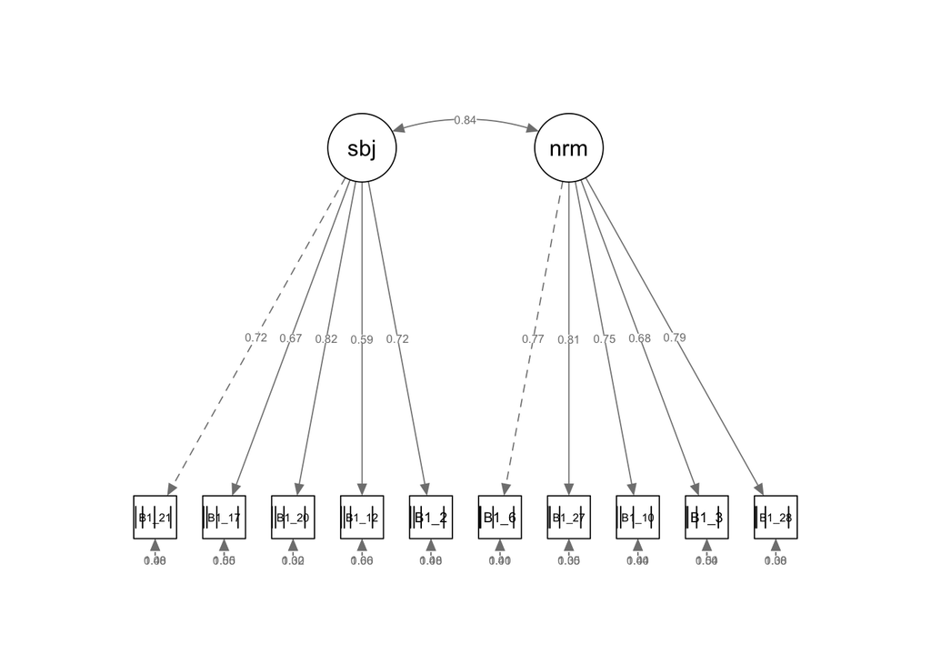

```r
fit <- cfa(model,data = capacidad, ordered = T)
#summary(fit, rsquare = T, fit.measures = T, standardized = T)
semPlot::semPaths(fit,whatLabels = 'std', style = 'lisrel', intercepts= F)
```

```r
min = fit |> broom::tidy() |> filter(op == "=~") |> pull(std.all) |> min() |> numformat()
max = fit |> broom::tidy() |> filter(op == "=~") |> pull(std.all) |> max() |> numformat()
```

Aquí podemos ver las cargas factoriales. Todas son significativas (p < .001), y de tamaños relativamente considerables (rango = .59 - .82.

```r
fit |>
  broom::tidy() |>
  filter(op == "=~") |>
  select(term, std.all, p.value) |>
  separate(term, c("Factor", "Item"), "=~") |>
  group_by(Factor) |>
  gt::gt() |>
  fmt_number(3)
```

| Item | std.all | p.value |
| --- | --- | --- |
| subj |  |  |
| B1_21 | 0.72 | NA |
| B1_17 | 0.67 | 0 |
| B1_20 | 0.82 | 0 |
| B1_12 | 0.59 | 0 |
| B1_2 | 0.72 | 0 |
| norm |  |  |
| B1_6 | 0.77 | NA |
| B1_27 | 0.81 | 0 |
| B1_10 | 0.75 | 0 |
| B1_33 | 0.68 | 0 |
| B1_28 | 0.79 | 0 |

```r
inspect(fit,what = "std.all")$psi |> as.data.frame() |> rownames_to_column() |> gt() |> fmt_number(2:3)
```

|  | subj | norm |
| --- | --- | --- |
| subj | 1.00 | 0.84 |
| norm | 0.84 | 1.00 |

### Confiabilidad

```r
capacidad |>
  select(B1_21,B1_17, B1_20, B1_12, B1_2) |>
  psych::alpha()
```

```
##
## Reliability analysis
## Call: psych::alpha(x = select(capacidad, B1_21, B1_17, B1_20, B1_12,
##     B1_2))
##
##   raw_alpha std.alpha G6(smc) average_r S/N   ase mean   sd median_r
##       0.77      0.77    0.74      0.39 3.3 0.024  4.4 0.97      0.4
##
##     95% confidence boundaries
##          lower alpha upper
## Feldt     0.71  0.77  0.81
## Duhachek  0.72  0.77  0.81
##
##  Reliability if an item is dropped:
##       raw_alpha std.alpha G6(smc) average_r S/N alpha se  var.r med.r
## B1_21      0.71      0.71    0.67      0.38 2.5    0.031 0.0124  0.38
## B1_17      0.73      0.73    0.69      0.40 2.6    0.029 0.0167  0.41
## B1_20      0.69      0.69    0.64      0.36 2.2    0.033 0.0094  0.35
## B1_12      0.77      0.77    0.72      0.46 3.3    0.025 0.0045  0.44
## B1_2       0.71      0.71    0.66      0.38 2.5    0.031 0.0044  0.40
##
##  Item statistics
##         n raw.r std.r r.cor r.drop mean  sd
## B1_21 234  0.76  0.74  0.64   0.56  3.9 1.5
## B1_17 234  0.71  0.71  0.60   0.53  4.4 1.3
## B1_20 234  0.78  0.79  0.73   0.63  4.6 1.3
## B1_12 234  0.60  0.62  0.46   0.39  4.7 1.3
## B1_2  234  0.74  0.74  0.67   0.57  4.5 1.3
##
## Non missing response frequency for each item
##          1    2    3    5    6 miss
## B1_21 0.05 0.16 0.28 0.38 0.14    0
## B1_17 0.02 0.08 0.23 0.50 0.18    0
## B1_20 0.01 0.08 0.20 0.49 0.22    0
## B1_12 0.01 0.07 0.15 0.51 0.26    0
## B1_2  0.02 0.08 0.17 0.53 0.20    0
```

```r
capacidad |>
  select(B1_6, B1_27, B1_10, B1_33, B1_28) |>
  psych::alpha()
```

```
##
## Reliability analysis
## Call: psych::alpha(x = select(capacidad, B1_6, B1_27, B1_10, B1_33,
##     B1_28))
##
##   raw_alpha std.alpha G6(smc) average_r S/N   ase mean   sd median_r
##        0.8       0.8    0.77      0.44   4 0.021  4.5 0.94     0.44
##
##     95% confidence boundaries
##          lower alpha upper
## Feldt     0.76   0.8  0.84
## Duhachek  0.76   0.8  0.84
##
##  Reliability if an item is dropped:
##       raw_alpha std.alpha G6(smc) average_r S/N alpha se  var.r med.r
## B1_6       0.74      0.74    0.69      0.42 2.9    0.027 0.0031  0.43
## B1_27      0.76      0.76    0.71      0.44 3.1    0.026 0.0034  0.44
## B1_10      0.76      0.76    0.71      0.44 3.2    0.026 0.0054  0.46
## B1_33      0.78      0.78    0.73      0.47 3.6    0.023 0.0014  0.48
## B1_28      0.76      0.76    0.71      0.44 3.2    0.025 0.0020  0.44
##
##  Item statistics
##         n raw.r std.r r.cor r.drop mean  sd
## B1_6  234  0.78  0.78  0.71   0.63  4.4 1.3
## B1_27 234  0.76  0.76  0.67   0.60  4.6 1.2
## B1_10 234  0.76  0.75  0.65   0.58  4.3 1.4
## B1_33 234  0.69  0.69  0.57   0.51  4.6 1.2
## B1_28 234  0.74  0.75  0.66   0.58  4.6 1.2
##
## Non missing response frequency for each item
##          1    2    3    5    6 miss
## B1_6  0.02 0.03 0.29 0.48 0.18    0
## B1_27 0.01 0.04 0.23 0.50 0.22    0
## B1_10 0.01 0.09 0.29 0.42 0.19    0
## B1_33 0.01 0.04 0.21 0.51 0.23    0
## B1_28 0.01 0.04 0.21 0.54 0.20    0
```

# Confiabilidad

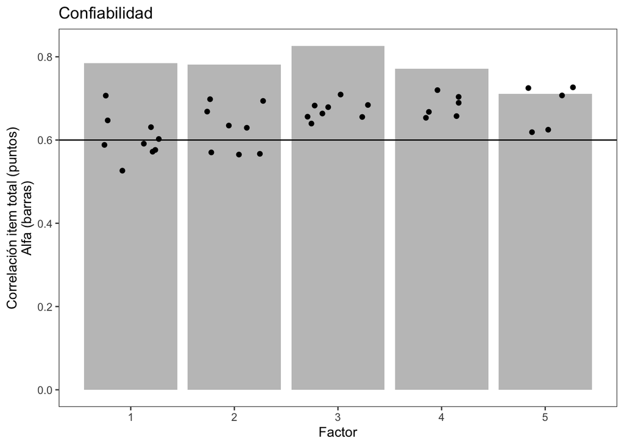

```r
model <- c(paste("f1 =~ ",paste0("B1_",1:9, collapse = '+')),
paste("f2 =~ ",paste0("B1_",10:17, collapse = '+')),
paste("f3 =~ ",paste0("B1_",18:25, collapse = '+')),
paste("f4 =~ ",paste0("B1_",26:31, collapse = '+')),
paste("f5 =~ ",paste0("B1_",32:36, collapse = '+')))

get_alpha <- function(i){capacidad |>
  select(model[i] |> str_sub(8) |> str_split("\\+",simplify = T) |> as.character()) |>
  psych::alpha()}

alfas =
  enframe(1:5) |>
  select(1) |>
  mutate(alpha = map(name, get_alpha)) |>
  mutate(
    result = map(alpha, "total"),
    scale_alfa = map_dbl(result, "std.alpha"),
    scale_mean = map_dbl(result, "mean"),
    scale_sd = map_dbl(result, "sd"),
    itemstats = map(alpha, "item.stats"),
    scores = map(alpha, "scores")
  ) |>
  unnest(itemstats) |>
  select(1, scale_alfa:sd,scores)
alfas |>
  ggplot(aes(name,raw.r))+
  geom_col(aes(y = scale_alfa),data = alfas |> select(name, scale_alfa) |> unique(), alpha = .4)+
  geom_point(position = position_jitter(width = .3))+
  geom_hline(yintercept = .6)+
  labs(title = "Confiabilidad",
       y = "Correlación item total (puntos)\nAlfa (barras)",
       x = "Factor")
```

```r
capacidad <-
  alfas |>
  select(name,scores) |>
  unique() |>
  spread(name,scores) |>
  unnest(everything()) |>
  rename_all(function(x)paste0("cap",x)) |>
  cbind(capacidad) |>
  select(colnames(capacidad), cap1:cap5) |>
  as_tibble()
```

# Correlaciones con otras variables

## Validez y confiabilidad de las otras variables

### PANAS

#### Análisis factorial exploratorio

```r
panas |>
  select(-1) |>
  psych::fa(nfactors = 2, rotate = 'varimax') |>
  Ben::gt_fatable(sort = F)
```

| Item | V1 | V2 |
| --- | --- | --- |
| C1_1 | .62 | -.06 |
| C1_2 | -.12 | .60 |
| C1_3 | .70 | -.11 |
| C1_4 | -.13 | .64 |
| C1_5 | -.12 | .68 |
| C1_6 | .70 | -.03 |
| C1_7 | .62 | -.14 |
| C1_8 | -.09 | .74 |
| C1_9 | -.09 | .61 |
| C1_10 | .80 | -.11 |
| C1_11 | -.00 | .70 |
| C1_12 | .82 | -.05 |
| C1_13 | .72 | -.21 |
| C1_14 | .60 | -.21 |
| C1_15 | -.08 | .72 |
| C1_16 | .74 | -.22 |
| C1_17 | -.12 | .75 |
| C1_18 | -.16 | .60 |
| C1_19 | .56 | .07 |
| C1_20 | -.07 | .53 |
| Summary statistics |  |  |
| Eigenvalues | 6.6747799 | 3.8605972 |
| Variance Explained | 0.2468101 | 0.2295664 |

#### Confiabilidad (factor 1)

```r
panas_keys <- panas |>
  select(-1) |>
  psych::fa(nfactors = 2, rotate = 'varimax') |>
  Ben::fa_tibble(sort = F) |>
  arrange(V2) |>
  mutate(factor=ifelse(V1> .30, "f1",'f2')) |>
  select(Item,factor)

panas |>
  select(panas_keys |> filter(factor == "f1") |> pull(Item)) |>
  psych::alpha()
```

```
##
## Reliability analysis
## Call: psych::alpha(x = select(panas, pull(filter(panas_keys, factor ==
##     "f1"), Item)))
##
##   raw_alpha std.alpha G6(smc) average_r S/N    ase mean   sd median_r
##        0.9       0.9    0.91      0.49 9.4 0.0092    3 0.83     0.49
##
##     95% confidence boundaries
##          lower alpha upper
## Feldt     0.89   0.9  0.92
## Duhachek  0.89   0.9  0.92
##
##  Reliability if an item is dropped:
##       raw_alpha std.alpha G6(smc) average_r S/N alpha se  var.r med.r
## C1_16      0.89      0.89    0.89      0.47 8.1   0.0106 0.0100  0.48
## C1_14      0.90      0.90    0.90      0.50 8.8   0.0098 0.0101  0.50
## C1_13      0.89      0.89    0.89      0.48 8.2   0.0104 0.0094  0.48
## C1_7       0.90      0.90    0.90      0.50 8.8   0.0098 0.0093  0.50
## C1_10      0.89      0.89    0.89      0.47 7.9   0.0109 0.0088  0.46
## C1_3       0.89      0.89    0.89      0.48 8.4   0.0102 0.0095  0.48
## C1_1       0.90      0.90    0.90      0.50 8.9   0.0098 0.0084  0.50
## C1_12      0.89      0.89    0.89      0.47 7.9   0.0110 0.0089  0.46
## C1_6       0.89      0.89    0.89      0.48 8.5   0.0102 0.0108  0.48
## C1_19      0.90      0.90    0.90      0.51 9.4   0.0093 0.0064  0.52
##
##  Item statistics
##         n raw.r std.r r.cor r.drop mean  sd
## C1_16 234  0.79  0.79  0.77   0.73  3.1 1.1
## C1_14 234  0.67  0.68  0.63   0.59  3.3 1.1
## C1_13 234  0.77  0.77  0.75   0.70  3.3 1.1
## C1_7  234  0.69  0.68  0.63   0.60  2.8 1.2
## C1_10 234  0.82  0.82  0.81   0.77  3.0 1.2
## C1_3  234  0.74  0.74  0.71   0.67  3.0 1.1
## C1_1  234  0.68  0.67  0.63   0.59  3.1 1.1
## C1_12 234  0.83  0.82  0.81   0.77  2.9 1.2
## C1_6  234  0.73  0.74  0.70   0.66  2.9 1.0
## C1_19 234  0.60  0.60  0.54   0.50  3.1 1.1
##
## Non missing response frequency for each item
##          1    2    3    4    5 miss
## C1_16 0.08 0.19 0.35 0.28 0.10    0
## C1_14 0.07 0.11 0.36 0.34 0.12    0
## C1_13 0.07 0.16 0.32 0.30 0.14    0
## C1_7  0.18 0.22 0.27 0.23 0.09    0
## C1_10 0.15 0.17 0.28 0.31 0.09    0
## C1_3  0.14 0.14 0.35 0.30 0.07    0
## C1_1  0.12 0.16 0.35 0.30 0.08    0
## C1_12 0.17 0.20 0.31 0.24 0.09    0
## C1_6  0.10 0.26 0.35 0.23 0.05    0
## C1_19 0.07 0.22 0.37 0.25 0.09    0
```

#### Confiabilidad (factor 2)

```r
panas |>
  select(panas_keys |> filter(factor == "f2") |> pull(Item)) |>
  psych::alpha()
```

```
##
## Reliability analysis
## Call: psych::alpha(x = select(panas, pull(filter(panas_keys, factor ==
##     "f2"), Item)))
##
##   raw_alpha std.alpha G6(smc) average_r S/N   ase mean   sd median_r
##       0.89      0.89    0.91      0.44   8 0.011  2.6 0.87     0.43
##
##     95% confidence boundaries
##          lower alpha upper
## Feldt     0.87  0.89  0.91
## Duhachek  0.87  0.89  0.91
##
##  Reliability if an item is dropped:
##       raw_alpha std.alpha G6(smc) average_r S/N alpha se var.r med.r
## C1_20      0.88      0.89    0.90      0.46 7.7    0.011 0.013  0.43
## C1_18      0.88      0.88    0.90      0.45 7.4    0.012 0.017  0.43
## C1_2       0.88      0.88    0.89      0.45 7.4    0.012 0.015  0.43
## C1_9       0.88      0.88    0.90      0.45 7.4    0.012 0.016  0.43
## C1_4       0.88      0.88    0.89      0.45 7.2    0.012 0.016  0.43
## C1_5       0.88      0.88    0.89      0.44 7.0    0.012 0.016  0.41
## C1_11      0.88      0.88    0.89      0.44 7.1    0.012 0.015  0.43
## C1_15      0.87      0.88    0.89      0.44 7.0    0.012 0.011  0.43
## C1_8       0.87      0.87    0.89      0.43 6.9    0.013 0.013  0.43
## C1_17      0.87      0.87    0.89      0.43 6.8    0.013 0.012  0.41
##
##  Item statistics
##         n raw.r std.r r.cor r.drop mean  sd
## C1_20 234  0.60  0.62  0.56   0.51  1.9 1.1
## C1_18 234  0.69  0.68  0.62   0.59  2.5 1.4
## C1_2  234  0.67  0.68  0.64   0.58  2.8 1.1
## C1_9  234  0.68  0.67  0.62   0.59  2.2 1.2
## C1_4  234  0.70  0.70  0.66   0.61  3.1 1.2
## C1_5  234  0.73  0.74  0.71   0.66  2.5 1.2
## C1_11 234  0.72  0.72  0.68   0.65  3.1 1.2
## C1_15 234  0.74  0.74  0.72   0.66  2.5 1.2
## C1_8  234  0.76  0.76  0.74   0.69  2.7 1.3
## C1_17 234  0.78  0.77  0.76   0.71  2.4 1.3
##
## Non missing response frequency for each item
##          1    2    3    4    5 miss
## C1_20 0.53 0.20 0.17 0.07 0.03    0
## C1_18 0.36 0.21 0.14 0.18 0.12    0
## C1_2  0.14 0.28 0.25 0.27 0.05    0
## C1_9  0.37 0.26 0.16 0.16 0.05    0
## C1_4  0.11 0.20 0.26 0.29 0.14    0
## C1_5  0.24 0.27 0.25 0.18 0.06    0
## C1_11 0.12 0.19 0.28 0.27 0.15    0
## C1_15 0.24 0.33 0.18 0.19 0.06    0
## C1_8  0.23 0.26 0.21 0.22 0.08    0
## C1_17 0.30 0.29 0.15 0.19 0.06    0
```

```r
panas <- panas |>
  Ben::create_composite(selection = c(C1_16, C1_14, C1_13,C1_7,C1_10,C1_3,C1_1,C1_12,C1_6,C1_19), name = positive) |>
  Ben::create_composite(selection = c(C1_20, C1_18, C1_2,C1_9,C1_4,C1_5,C1_11,C1_15,C1_8,C1_17), name = negative)
```

### Familia

```r
familia |> select(-id) |> psych::fa.parallel(plot= F, cor = 'poly')
```

```
## Parallel analysis suggests that the number of factors =  4  and the number of components =  1
```

#### Análisis factorial

```r
familia |> select(-id) |> psych::fa() |> Ben::gt_fatable(sort = F)
```

| Item | V1 |
| --- | --- |
| E1 | -.02 |
| E2 | -.69 |
| E3 | -.72 |
| E4 | .45 |
| E5 | .66 |
| E6 | .59 |
| E7 | .67 |
| E8 | -.60 |
| E9 | .81 |
| E10 | -.64 |
| E11 | .64 |
| E12 | -.50 |
| Summary statistics |  |
| Eigenvalues | 5.0849421 |
| Variance Explained | 0.3773264 |

#### Confiabilidad

```r
familia |> mutate_at(c(2,3,4,9,11,13),function(x)8-x) |> select(-1) |> psych::alpha()
```

```
##
## Reliability analysis
## Call: psych::alpha(x = select(mutate_at(familia, c(2, 3, 4, 9, 11,
##     13), function(x) 8 - x), -1))
##
##   raw_alpha std.alpha G6(smc) average_r S/N   ase mean  sd median_r
##       0.86      0.86    0.87      0.34 6.1 0.013  4.2 1.1     0.38
##
##     95% confidence boundaries
##          lower alpha upper
## Feldt     0.83  0.86  0.89
## Duhachek  0.84  0.86  0.89
##
##  Reliability if an item is dropped:
##     raw_alpha std.alpha G6(smc) average_r S/N alpha se var.r med.r
## E1       0.88      0.88    0.88      0.40 7.4    0.012 0.010  0.40
## E2       0.84      0.84    0.85      0.32 5.2    0.015 0.035  0.36
## E3       0.84      0.84    0.85      0.32 5.2    0.015 0.033  0.36
## E4       0.86      0.86    0.87      0.35 6.0    0.013 0.032  0.40
## E5       0.84      0.84    0.86      0.33 5.3    0.014 0.034  0.37
## E6       0.85      0.85    0.86      0.34 5.6    0.014 0.033  0.38
## E7       0.84      0.84    0.86      0.33 5.3    0.014 0.033  0.36
## E8       0.85      0.85    0.86      0.33 5.5    0.014 0.035  0.37
## E9       0.83      0.83    0.85      0.31 5.0    0.015 0.030  0.36
## E10      0.85      0.84    0.86      0.33 5.4    0.014 0.033  0.38
## E11      0.85      0.84    0.86      0.33 5.4    0.014 0.033  0.38
## E12      0.86      0.85    0.87      0.35 5.8    0.013 0.034  0.39
##
##  Item statistics
##       n raw.r std.r r.cor r.drop mean  sd
## E1  234  0.12  0.14 0.029 0.0076  5.3 1.5
## E2  234  0.73  0.74 0.716 0.6629  4.7 1.7
## E3  234  0.75  0.75 0.730 0.6783  4.4 1.8
## E4  234  0.51  0.50 0.433 0.3978  4.6 1.9
## E5  234  0.70  0.70 0.667 0.6228  3.9 1.7
## E6  234  0.63  0.63 0.585 0.5360  3.3 1.8
## E7  234  0.70  0.70 0.668 0.6200  3.7 1.9
## E8  234  0.66  0.65 0.610 0.5632  4.4 2.0
## E9  234  0.81  0.80 0.803 0.7499  4.2 1.8
## E10 234  0.66  0.67 0.637 0.5875  4.1 1.4
## E11 234  0.67  0.67 0.634 0.5882  4.0 1.8
## E12 234  0.56  0.56 0.494 0.4570  3.7 1.8
##
## Non missing response frequency for each item
##        1    2    3    4    5    6    7 miss
## E1  0.02 0.04 0.06 0.17 0.21 0.24 0.27    0
## E2  0.06 0.04 0.10 0.19 0.24 0.21 0.15    0
## E3  0.09 0.07 0.15 0.19 0.21 0.15 0.15    0
## E4  0.07 0.12 0.10 0.15 0.18 0.21 0.18    0
## E5  0.14 0.10 0.16 0.17 0.26 0.13 0.04    0
## E6  0.24 0.14 0.13 0.22 0.16 0.07 0.05    0
## E7  0.23 0.05 0.15 0.16 0.23 0.12 0.06    0
## E8  0.10 0.09 0.15 0.17 0.12 0.17 0.20    0
## E9  0.11 0.09 0.15 0.20 0.20 0.12 0.14    0
## E10 0.06 0.06 0.18 0.31 0.21 0.14 0.04    0
## E11 0.11 0.12 0.19 0.18 0.21 0.09 0.11    0
## E12 0.13 0.15 0.26 0.16 0.10 0.12 0.09    0
```

```r
familia <-
  familia |>
  #invert items
  mutate_at(c(2,3,4,9,11,13),function(x)8-x) |>
  Ben::create_composite(E1:E12,name = familia)
```

### Flourishing

```r
flour |> select(-1) |> psych::fa.parallel(plot = F, cor = 'poly')
```

```
## Parallel analysis suggests that the number of factors =  1  and the number of components =  1
```

#### Análisis Factorial

```r
flour |> select(-1) |> psych::fa() |> Ben::gt_fatable(sort = F)
```

| Item | V1 |
| --- | --- |
| D1_1 | .78 |
| D1_2 | .69 |
| D1_3 | .78 |
| D1_4 | .61 |
| D1_5 | .72 |
| D1_6 | .81 |
| D1_7 | .74 |
| D1_8 | .65 |
| Summary statistics |  |
| Eigenvalues | 4.6594222 |
| Variance Explained | 0.5247219 |

#### Confiabilidad

```r
flour |> select(-1) |> psych::alpha()
```

```
##
## Reliability analysis
## Call: psych::alpha(x = select(flour, -1))
##
##   raw_alpha std.alpha G6(smc) average_r S/N  ase mean  sd median_r
##        0.9       0.9     0.9      0.52 8.7 0.01  4.9 1.1     0.53
##
##     95% confidence boundaries
##          lower alpha upper
## Feldt     0.87   0.9  0.92
## Duhachek  0.88   0.9  0.92
##
##  Reliability if an item is dropped:
##      raw_alpha std.alpha G6(smc) average_r S/N alpha se  var.r med.r
## D1_1      0.88      0.88    0.87      0.51 7.3    0.012 0.0052  0.52
## D1_2      0.88      0.89    0.88      0.53 7.7    0.011 0.0081  0.53
## D1_3      0.88      0.88    0.87      0.51 7.3    0.012 0.0051  0.52
## D1_4      0.89      0.89    0.89      0.54 8.3    0.011 0.0061  0.55
## D1_5      0.88      0.88    0.88      0.52 7.6    0.011 0.0074  0.54
## D1_6      0.88      0.88    0.87      0.50 7.1    0.012 0.0067  0.49
## D1_7      0.88      0.88    0.88      0.52 7.5    0.012 0.0067  0.52
## D1_8      0.89      0.89    0.88      0.53 8.0    0.011 0.0072  0.54
##
##  Item statistics
##        n raw.r std.r r.cor r.drop mean  sd
## D1_1 234  0.81  0.80  0.77   0.73  4.6 1.7
## D1_2 234  0.74  0.74  0.69   0.66  4.8 1.5
## D1_3 234  0.81  0.80  0.78   0.73  4.6 1.5
## D1_4 234  0.67  0.69  0.62   0.58  4.9 1.4
## D1_5 234  0.74  0.76  0.71   0.67  5.3 1.3
## D1_6 234  0.83  0.82  0.80   0.76  5.0 1.5
## D1_7 234  0.78  0.77  0.74   0.70  4.8 1.7
## D1_8 234  0.70  0.71  0.66   0.61  5.2 1.3
##
## Non missing response frequency for each item
##         1    2    3    4    5    6    7 miss
## D1_1 0.06 0.11 0.09 0.13 0.25 0.25 0.11    0
## D1_2 0.03 0.07 0.08 0.14 0.28 0.32 0.08    0
## D1_3 0.03 0.07 0.13 0.16 0.29 0.22 0.09    0
## D1_4 0.03 0.03 0.07 0.18 0.31 0.31 0.07    0
## D1_5 0.01 0.03 0.06 0.10 0.27 0.39 0.14    0
## D1_6 0.03 0.06 0.06 0.17 0.19 0.38 0.12    0
## D1_7 0.04 0.11 0.06 0.14 0.23 0.31 0.11    0
## D1_8 0.01 0.04 0.02 0.17 0.25 0.41 0.09    0
```

```r
flour <- flour |> Ben::create_composite(D1_1:D1_8,name = flour)
```

### Merge

Ahora unimos los puntajes totales calculados

```r
base_limpia <- left_join(demo,capacidad) |>
  left_join(panas) |>
  left_join(flour) |>
  left_join(familia)
base_totales <- left_join(demo,capacidad |> select(id,cap1:cap5)) |>
  left_join(panas |> select(id, positive, negative)) |>
  left_join(flour |> select(id, flour)) |>
  left_join(familia |> select(id,familia))
```

## Evidencias de validez convergente y discriminante

### A nivel de items

```r
cors = capacidad |>
  left_join(base_totales) |>
  select(starts_with("B1"), positive, negative, flour, familia) |>
  corrr::correlate() |>
  corrr::stretch() |>
  filter(x %in% items$var) |>
  filter(!(y %in% items$var))

cors |>
  pivot_wider(names_from = y, values_from = r) |>
  left_join(items |> select(x = var, item)) |>
  select(x, item, everything()) |>
  gt::gt() |>
  fmt_number(3:6,decimals = 3)
```

| x | item | positive | negative | flour | familia |
| --- | --- | --- | --- | --- | --- |
| B1_1 | Me siento capaz de manejar el estrés en mis actividades académicas y/o laborales. | 0.403 | −0.418 | 0.354 | 0.062 |
| B1_2 | Me siento capaz de defender mis ideas cuando la situación lo demanda. | 0.356 | −0.342 | 0.450 | 0.094 |
| B1_3 | Los otros piensan que soy capaz de manejar mis responsabilidades académicas y/o laborales. | 0.156 | −0.266 | 0.350 | 0.114 |
| B1_4 | Me siento capaz de escuchar a los otros. | 0.214 | −0.297 | 0.294 | 0.020 |
| B1_5 | Los otros piensan que soy capaz de dar buenos consejos. | 0.183 | −0.121 | 0.245 | −0.008 |
| B1_6 | Los otros piensan que tengo una argumentación analítica y práctica. | 0.222 | −0.152 | 0.344 | 0.117 |
| B1_7 | Me siento capaz de trabajar bajo presión. | 0.235 | −0.216 | 0.281 | 0.124 |
| B1_8 | Me siento capaz de encontrar ideas innovadoras. | 0.509 | −0.195 | 0.299 | 0.045 |
| B1_9 | Me siento capaz de asumir distintas tareas en mis actividades académicas y/o laborales. | 0.448 | −0.340 | 0.390 | 0.013 |
| B1_10 | Los otros piensan que soy una persona segura de sí misma. | 0.359 | −0.207 | 0.379 | 0.132 |
| B1_11 | Me siento capaz de alentar a las personas para que den lo mejor de sí mismas. | 0.243 | −0.179 | 0.264 | 0.072 |
| B1_12 | Me siento capaz de tener la curiosidad necesaria para buscar y encontrar información adicional. | 0.410 | −0.167 | 0.242 | −0.051 |
| B1_13 | Los otros piensan que tengo capacidades de líder. | 0.334 | −0.197 | 0.262 | 0.116 |
| B1_14 | Los otros piensan que tengo facilidad para establecer buenas relaciones con los demás. | 0.350 | −0.175 | 0.294 | 0.086 |
| B1_15 | Me siento capaz de ser autónomo en mis actividades académicas y/o laborales. | 0.352 | −0.326 | 0.355 | 0.062 |
| B1_16 | Los otros piensan que soy capaz de manejar mi tiempo para realizar mis actividades académicas y/o laborales dentro de los plazos establecidos. | 0.185 | −0.277 | 0.258 | 0.050 |
| B1_17 | Me siento capaz de mantener la objetividad en mis actividades académicas y/o laborales. | 0.320 | −0.444 | 0.297 | 0.051 |
| B1_18 | Los otros piensan que soy capaz de comunicarme bien con los demás. | 0.300 | −0.256 | 0.360 | 0.133 |
| B1_19 | Los otros piensan que soy capaz de manejar el estrés. | 0.230 | −0.243 | 0.335 | 0.084 |
| B1_20 | Me siento capaz de sustentar mi discurso a partir de hechos concretos. | 0.360 | −0.158 | 0.409 | 0.040 |
| B1_21 | Me siento capaz de sentir confianza en mí mismo y demostrarlo. | 0.543 | −0.454 | 0.445 | 0.114 |
| B1_22 | Los otros piensan que soy capaz de realizar tareas diversas de manera muy satisfactoria. | 0.278 | −0.257 | 0.341 | 0.022 |
| B1_23 | Me siento capaz de tener buenas relaciones con las personas. | 0.391 | −0.404 | 0.466 | 0.205 |
| B1_24 | Me siento capaz de manejar las responsabilidades relacionadas con mis actividades académicas y/o laborales. | 0.447 | −0.475 | 0.354 | 0.087 |
| B1_25 | Los otros piensan que soy capaz de proponer nuevas ideas cuando la situación lo demanda. | 0.368 | −0.092 | 0.301 | 0.138 |
| B1_26 | Me siento capaz de dirigir a otras personas. | 0.321 | −0.279 | 0.333 | 0.137 |
| B1_27 | Los otros piensan que tengo la capacidad de defender mis ideas si hace falta. | 0.352 | −0.195 | 0.387 | 0.162 |
| B1_28 | Los otros piensan que soy capaz de ser objetivo en mis actividades académicas y/o laborales. | 0.284 | −0.288 | 0.325 | 0.191 |
| B1_29 | Me siento capaz de organizar mis actividades académicas y/o laborales para terminarlo a tiempo. | 0.366 | −0.430 | 0.311 | 0.054 |
| B1_30 | Los otros piensan que tengo la capacidad de escucha desarrollada. | 0.259 | −0.251 | 0.253 | 0.035 |
| B1_31 | Los otros piensan que resisto bien la presión. | 0.224 | −0.241 | 0.278 | 0.041 |
| B1_32 | Me siento capaz de comunicarme sin problemas con mis compañeros. | 0.372 | −0.441 | 0.446 | 0.190 |
| B1_33 | Los otros piensan que soy una persona curiosa y abierta a nuevos conocimientos. | 0.379 | −0.231 | 0.392 | 0.117 |
| B1_34 | Me siento capaz de dar buenos consejos. | 0.209 | −0.164 | 0.247 | −0.045 |
| B1_35 | Los otros piensan que soy muy autónomo. | 0.365 | −0.286 | 0.281 | 0.008 |
| B1_36 | Los otros piensan que tengo la capacidad de alentar a los demás. | 0.264 | −0.186 | 0.259 | 0.034 |

[figure not shown]

```r
cors |>
  left_join(items |> select(x = var, item)) |>
  ggplot(aes(item,y,fill=r))+
  geom_tile()+
  coord_flip()+
  geom_text(aes(label = Ben::numformat(r)))+
  egg::theme_article()+
  theme(legend.position = "bottom")+
  scale_fill_viridis_c()
```

### Entre las variables

```r
base_totales |>
  select(-id,-A3) |>
  fastDummies::dummy_cols(remove_selected_columns = T,remove_first_dummy = F) |>
  select(cap1:familia) |>
  Ben::harcor() |>
  gt::gt()
```

|  | 1 | 2 | 3 | 4 | 5 | 6 | 7 | 8 | 9 |
| --- | --- | --- | --- | --- | --- | --- | --- | --- | --- |
| 1. cap1 |  |  |  |  |  |  |  |  |  |
| 2. cap2 | .77*** |  |  |  |  |  |  |  |  |
| 3. cap3 | .83*** | .81*** |  |  |  |  |  |  |  |
| 4. cap4 | .80*** | .80*** | .81*** |  |  |  |  |  |  |
| 5. cap5 | .72*** | .79*** | .76*** | .73*** |  |  |  |  |  |
| 6. positive | .51*** | .50*** | .55*** | .44*** | .47*** |  |  |  |  |
| 7. negative | -.43*** | -.39*** | -.44*** | -.42*** | -.39*** | -.27*** |  |  |  |
| 8. flour | .55*** | .46*** | .56*** | .46*** | .48*** | .36*** | -.42*** |  |  |
| 9. familia | .11† | .10 | .16* | .15* | .09 | .09 | -.15* | .20** |  |
| M | 4.42 | 4.44 | 4.33 | 4.38 | 4.52 | 2.86 | 2.44 | 3.44 | 3.52 |
| SD | 0.78 | 0.84 | 0.91 | 0.92 | 0.88 | 0.75 | 0.79 | 0.77 | 0.81 |
| n | 234 | 234 | 234 | 234 | 234 | 234 | 234 | 234 | 234 |

### Entre las capacidades y los demograficos

```r
base_totales |>
  select(-id,-A3) |>
  fastDummies::dummy_cols(remove_selected_columns = T,remove_first_dummy = F) |>
  select(-flour,-positive,-negative,-familia) |>
  select(cap1:cap5,A6,everything()) |>
  Ben::harcor() |>
  slice(6:77) |>
  select(1:6) |>
  gt::gt()
```

|  | 1 | 2 | 3 | 4 | 5 |
| --- | --- | --- | --- | --- | --- |
| 6. A6 | .00 | .09 | .07 | .00 | .05 |
| 7. A1_No | .00 | .00 | -.01 | -.08 | .01 |
| 8. A1_Sí | .00 | .00 | .01 | .08 | -.01 |
| 9. A2_Facultad de Arquitectura y Urbanismo | -.09 | -.15* | -.10 | -.13* | -.10 |
| 10. A2_Facultad de Arte y Diseño | .05 | .06 | .05 | -.01 | .02 |
| 11. A2_Facultad de Artes Escénicas | .02 | .06 | .02 | .09 | .08 |
| 12. A2_Facultad de Ciencias Contables | .07 | .14* | .08 | .11† | .09 |
| 13. A2_Facultad de Ciencias e Ingeniería | -.05 | -.05 | -.02 | -.07 | -.05 |
| 14. A2_Facultad de Ciencias Sociales | .05 | -.03 | .02 | .03 | .00 |
| 15. A2_Facultad de Ciencias y Artes de la Comunicación | .06 | .10 | .10 | .07 | .07 |
| 16. A2_Facultad de Derecho | -.05 | -.04 | .00 | .03 | -.03 |
| 17. A2_Facultad de Educación | -.01 | .09 | .01 | .05 | .07 |
| 18. A2_Facultad de Estudios Interdisciplinarios | .09 | .05 | .05 | .03 | .07 |
| 19. A2_Facultad de Gestión y Alta Dirección | .01 | .03 | -.04 | .02 | -.03 |
| 20. A2_Facultad de Letras y Ciencias Humanas | -.05 | -.06 | -.16* | -.08 | -.04 |
| 21. A2_Facultad de Psicología | .00 | .00 | .03 | -.01 | .04 |
| 22. A4_Cuarto | -.01 | -.04 | -.02 | -.03 | .00 |
| 23. A4_Décimo | .11† | .14* | .12† | .14* | .10 |
| 24. A4_Noveno | -.08 | -.02 | -.06 | -.05 | -.02 |
| 25. A4_Octavo | .09 | .15* | .12† | .16* | .16* |
| 26. A4_Quinto | -.03 | -.09 | -.06 | -.02 | -.07 |
| 27. A4_Segundo | .00 | -.01 | .02 | -.05 | -.01 |
| 28. A4_Séptimo | .02 | .03 | -.01 | -.02 | -.02 |
| 29. A4_Sexto | -.06 | -.07 | -.04 | -.04 | -.04 |
| 30. A4_Tercer | -.01 | -.06 | -.03 | -.05 | -.07 |
| 31. A5_Femenino | .04 | .06 | .03 | .03 | .13* |
| 32. A5_Masculino | -.02 | -.03 | .01 | -.01 | -.10 |
| 33. A5_No binario | .01 | -.03 | -.05 | -.04 | -.02 |
| 34. A5_Prefiero no decir | -.09 | -.11† | -.09 | -.07 | -.09 |
| 35. A7_No | -.14* | -.20** | -.16* | -.17** | -.11 |
| 36. A7_Sí | .14* | .20** | .16* | .17** | .11 |
| 37. A8_No | -.15* | -.20** | -.20** | -.15* | -.15* |
| 38. A8_Sí | .15* | .20** | .20** | .15* | .15* |
| 39. A9_19 | -.02 | -.01 | -.11 | -.17 | -.03 |
| 40. A9_2006 | .02 | -.05 | .01 | -.11 | -.06 |
| 41. A9_2007 | .27† | .22 | .26† | .23 | .20 |
| 42. A9_2010 | .05 | -.25† | -.11 | -.06 | -.29† |
| 43. A9_2015 | .00 | .20 | .14 | .15 | .04 |
| 44. A9_2016 | -.11 | -.20 | -.16 | -.23 | -.11 |
| 45. A9_2017 | .05 | .09 | .07 | .02 | .03 |
| 46. A9_2019 | -.10 | -.13 | -.04 | -.04 | -.01 |
| 47. A9_2020 | -.18 | -.15 | -.13 | -.12 | -.11 |
| 48. A9_2021 | .17 | .27† | .26† | .23 | .30* |
| 49. A9_2022 | -.01 | -.09 | -.13 | -.01 | -.06 |
| 50. A9_2022-1 | -.09 | .04 | -.14 | -.03 | -.26† |
| 51. A9_Primero | -.06 | -.03 | .01 | -.09 | .04 |
| 52. A9_NA | -.15* | -.20** | -.20** | -.15* | -.15* |
| 53. A10_Por horas | -.24 | -.12 | -.27† | -.18 | -.14 |
| 54. A10_Tiempo completo (40hr) | .30* | .15 | .30* | .19 | .10 |
| 55. A10_Tiempo parcial (20hr) | -.01 | -.01 | .02 | .03 | .05 |
| 56. A10_NA | -.15* | -.20** | -.20** | -.15* | -.15* |
| 57. A11_4 | -.62** | -.42† | -.15 | -.28 | -.15 |
| 58. A11_6 | .43† | .51* | .71** | .43† | .52* |
| 59. A11_8 | .07 | .04 | -.15 | -.28 | .00 |
| 60. A11_8h | .17 | .04 | -.21 | .25 | .07 |
| 61. A11_10 | .07 | -.42† | -.09 | -.39 | -.38 |
| 62. A11_10-24 | -.09 | .16 | -.21 | .02 | -.52* |
| 63. A11_12 | -.15 | -.07 | -.21 | -.04 | .00 |
| 64. A11_15 | .02 | .02 | .05 | -.06 | .26 |
| 65. A11_16 | .49* | -.07 | .03 | .31 | .00 |
| 66. A11_20 | -.20 | -.19 | -.21 | -.10 | .14 |
| 67. A11_30 | -.06 | .26 | .38 | .33 | .03 |
| 68. A11_36 | -.04 | .04 | .03 | -.28 | .07 |
| 69. A11_55 | -.04 | -.13 | -.27 | -.16 | -.15 |
| 70. A11_NA | .00 | -.07 | -.03 | -.02 | -.03 |
| M | 4.42 | 4.44 | 4.33 | 4.38 | 4.52 |
| SD | 0.78 | 0.84 | 0.91 | 0.92 | 0.88 |
| n | 234 | 234 | 234 | 234 | 234 |